# Experiment 1_WAP

Chris Wahlheim

12/29/2019

```r
#Clear Environment
rm(list=ls())
```

```r
#Load packages
library(tidyverse)
library(lme4)
library(car)
library(emmeans)
library(gridExtra)
#Read 1803.2 data
cued_recall <- read.csv("Experiment_1_Fake_News.csv", stringsAsFactors = FALSE, fileEncoding="UTF-8-BOM")
```

```r
#create binary variable for each Phase 1 recall response type
cued_recall$P1_Correct <- ifelse(cued_recall$P1.Recall.Class == 1, 1, 0)
cued_recall$P1_P2_Baseline_Production <- ifelse(cued_recall$P1.Recall.Class == 2, 1, 0)
cued_recall$P1_Error <- ifelse(cued_recall$P1.Recall.Class == "E", 1, 0)

#Create binary variables for each Phase 2 recall response type
cued_recall$P2_Correct <- ifelse(cued_recall$P2.Recall.Class == "2", 1, 0)
cued_recall$P1_Intrusion <- ifelse(cued_recall$P2.Recall.Class == "1", 1, 0)
cued_recall$Ambiguous <- ifelse(cued_recall$P2.Recall.Class == "A", 1, 0)
cued_recall$Error <- ifelse(cued_recall$P2.Recall.Class == "E", 1, 0)
```

```r
#create variable including labels for each classification type
cued_recall$Correction_Class <- ifelse(cued_recall$CR.RESP == 1 & cued_recall$P1_Correct == 1, "Misinformation Recollected",
                                ifelse(cued_recall$CR.RESP == 1 & cued_recall$P1_Correct == 0, "Correction Remembered", "Correction Not Remembered"))

#create binary variables for each classification type
cued_recall$Misinformation_Recollected <- ifelse(cued_recall$Correction_Class == "Misinformation Recollected", 1, 0)
cued_recall$Correction_Remembered <- ifelse(cued_recall$Correction_Class == "Correction Remembered", 1, 0)
cued_recall$Correction_Not_Remembered <- ifelse(cued_recall$Correction_Class == "Correction Not Remembered", 1, 0)
```

```r
#Set factors
cued_recall$Subject <- as.factor(cued_recall$Subject)
cued_recall$Topic <- as.factor(cued_recall$Topic)
cued_recall$ItemType <- as.factor(cued_recall$ItemType)
cued_recall$Change_Class <- as.factor(cued_recall$Correction_Class)
```

```r
#change factor level names
cued_recall$ItemType <- gsub("Repeated", "Repetition", cued_recall$ItemType)
cued_recall$ItemType <- gsub("Changed_NR", "Correction", cued_recall$ItemType)
cued_recall$ItemType <- gsub("Changed_R", "Retraction", cued_recall$ItemType)
```

```r
#Create variable for control in glmers
moreControl <- glmerControl(optimizer = "bobyqa", optCtrl = list(maxfun = 2e4))
```

Fit Mixed Effects Model to Correct Facts Data

```r
#gmler for list 2 recall data (all responses)
p2_recall_glmer <- glmer(P2_Correct ~ ItemType + (1 | Subject) + (1 | Topic), family = binomial, data = cued_recall)

#Run ANOVA for List 2 recall for all item types
Anova(p2_recall_glmer)
```

```
## Analysis of Deviance Table (Type II Wald chisquare tests)
##
## Response: P2_Correct
##           Chisq Df Pr(>Chisq)
## ItemType 256.69  3  < 2.2e-16 ***
## ---
## Signif. codes:  0 '***' 0.001 '**' 0.01 '*' 0.05 '.' 0.1 ' ' 1
```

```r
#Pairwise comparisons for List 2 recall for all items types
p2_recall_emmeans <- emmeans(p2_recall_glmer, list(pairwise ~ ItemType), type = "response")
p2_recall_emmeans
```

```
## $`emmeans of ItemType`
##  ItemType    prob    SE  df asymp.LCL asymp.UCL
##  Control    0.520 0.046 Inf     0.430     0.608
##  Correction 0.483 0.046 Inf     0.395     0.573
##  Repetition 0.737 0.036 Inf     0.661     0.802
##  Retraction 0.749 0.035 Inf     0.674     0.811
##
## Confidence level used: 0.95
## Intervals are back-transformed from the logit scale
##
## $`pairwise differences of ItemType`
##  1                       odds.ratio     SE  df z.ratio p.value
##  Control / Correction         1.158 0.1020 Inf   1.661 0.3445
##  Control / Repetition         0.386 0.0355 Inf -10.352 <.0001
##  Control / Retraction         0.363 0.0337 Inf -10.927 <.0001
##  Correction / Repetition      0.333 0.0307 Inf -11.909 <.0001
##  Correction / Retraction      0.314 0.0291 Inf -12.477 <.0001
##  Repetition / Retraction      0.941 0.0888 Inf  -0.641 0.9186
##
## P value adjustment: tukey method for comparing a family of 4 estimates
## Tests are performed on the log odds ratio scale
```

```r
#extract estimated probabilities
p2_recall_emmeans_df <- as_tibble(p2_recall_emmeans$`emmeans of ItemType`)
p2_recall_emmeans_df
```

```
## # A tibble: 4 x 6
##   ItemType    prob     SE    df asymp.LCL asymp.UCL
##   <fct>      <dbl>  <dbl> <dbl>     <dbl>     <dbl>
## 1 Control    0.520 0.0460   Inf     0.430     0.608
## 2 Correction 0.483 0.0460   Inf     0.395     0.573
## 3 Repetition 0.737 0.0360   Inf     0.661     0.802
## 4 Retraction 0.749 0.0350   Inf     0.674     0.811
```

```r
#reorder factor levels
p2_recall_emmeans_df$ItemType <- factor(p2_recall_emmeans_df$ItemType, levels = c("Repetition", "Control", "Correction", "Retraction"))

#set x position for model-estimated probabilities and confidence intervals
p2_recall_emmeans_df$ci_point <- c(1.7, 2.7, 0.7, 3.7)

#create variable for response type
p2_recall_emmeans_df$ResponseType <- "Correct Facts"


p2_recall_emmeans_df
```

```
## # A tibble: 4 x 8
##   ItemType    prob     SE    df asymp.LCL asymp.UCL ci_point ResponseType
##   <fct>      <dbl>  <dbl> <dbl>     <dbl>     <dbl>    <dbl> <chr>
## 1 Control    0.520 0.0460   Inf     0.430     0.608      1.7 Correct Facts
## 2 Correction 0.483 0.0460   Inf     0.395     0.573      2.7 Correct Facts
## 3 Repetition 0.737 0.0360   Inf     0.661     0.802      0.7 Correct Facts
## 4 Retraction 0.749 0.0350   Inf     0.674     0.811      3.7 Correct Facts
```

Create Correct Facts data frame including individual subject means

```r
#data frame to summarize list 2 recall for individual subjects
p2_recall_sub_df <- cued_recall %>%
                    group_by(Subject, ItemType) %>%
                    summarise(prob = mean(P2_Correct)) %>%
                    as_tibble()
```

```r
p2_recall_sub_df$prob <- ifelse(p2_recall_sub_df$prob == 0, .025, p2_recall_sub_df$prob)

#reorder factor levels
p2_recall_sub_df$ItemType <- factor(p2_recall_sub_df$ItemType, levels = c("Repetition", "Control", "Correction", "Retraction"))

#set x axis position for box plots
p2_recall_sub_df$x_box_pos <- if_else(p2_recall_sub_df$ItemType == "Repetition", "1",
                              if_else(p2_recall_sub_df$ItemType == "Control", "2",
                              if_else(p2_recall_sub_df$ItemType == "Correction", "3",
                              if_else(p2_recall_sub_df$ItemType == "Retraction", "4","na")))) %>% as.numeric()

#set x axis position for point plots
p2_recall_sub_df$x_pnt_pos <- if_else(p2_recall_sub_df$ItemType == "Repetition", "1.3",
                              if_else(p2_recall_sub_df$ItemType == "Control", "2.3",
                              if_else(p2_recall_sub_df$ItemType == "Correction", "3.3",
                              if_else(p2_recall_sub_df$ItemType == "Retraction", "4.3","na")))) %>% as.numeric()

#create variable for response type
p2_recall_sub_df$ResponseType <- "Correct Facts"

p2_recall_sub_df
```

```
## # A tibble: 384 x 6
##    Subject ItemType    prob x_box_pos x_pnt_pos ResponseType
##    <fct>   <fct>      <dbl>     <dbl>     <dbl> <chr>
##  1 101     Control    0.6           2       2.3 Correct Facts
##  2 101     Correction 0.8           3       3.3 Correct Facts
##  3 101     Repetition 0.8           1       1.3 Correct Facts
##  4 101     Retraction 0.867         4       4.3 Correct Facts
##  5 102     Control    0.333         2       2.3 Correct Facts
##  6 102     Correction 0.6           3       3.3 Correct Facts
##  7 102     Repetition 0.733         1       1.3 Correct Facts
##  8 102     Retraction 0.8           4       4.3 Correct Facts
##  9 103     Control    0.533         2       2.3 Correct Facts
## 10 103     Correction 0.4           3       3.3 Correct Facts
## # … with 374 more rows
```

Visualize Overall List 2 Recall

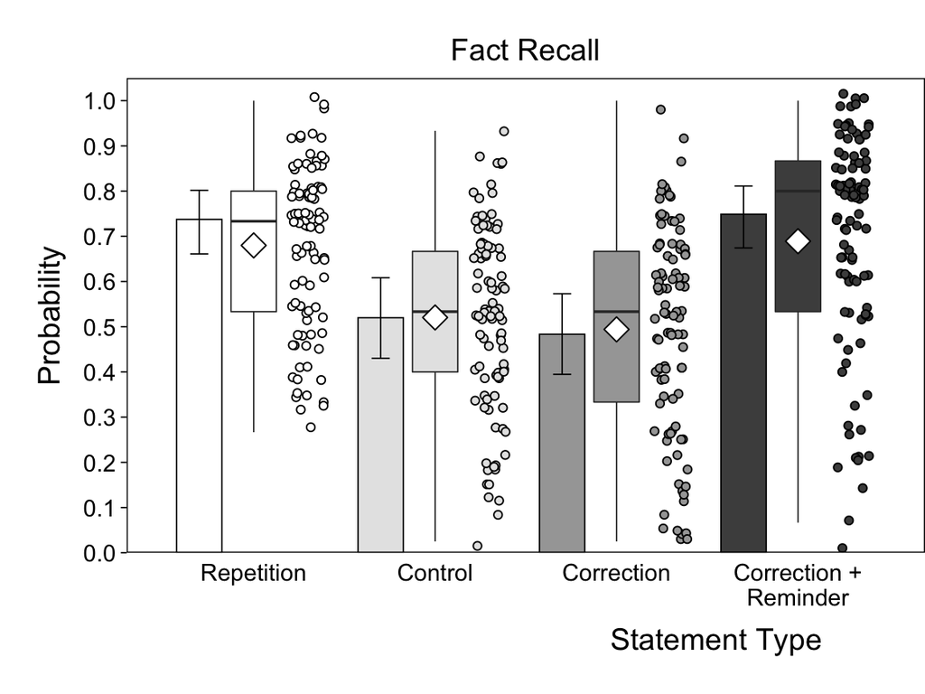

```r
#Visualize list 2 recall responses
l2_recall_all <- ggplot(p2_recall_sub_df, aes(x = ItemType, y = prob)) +
                 geom_boxplot(aes(fill = ItemType, x = x_box_pos), outlier.size = -1, size = .3, width = .25) +
                 geom_point(aes(fill = ItemType, x = x_pnt_pos), shape = 21, size = 1.5,
                            position = position_jitterdodge(jitter.width = .55, jitter.height = .02),
                            color = "black", stroke = .5, alpha = 1, show.legend = FALSE) +
                 stat_summary(aes(x = x_box_pos), fun.y = "mean", size = 4, shape = 23, color = "black", fill = "white", geom = "point") +
                 geom_bar(data = p2_recall_emmeans_df, aes(fill = ItemType, x = ci_point), stat = "identity",
                          width = .25, size = .3, color = "black", position = position_dodge()) +
                 geom_errorbar(data = p2_recall_emmeans_df, aes(ymin = asymp.LCL, ymax = asymp.UCL, x = ci_point),
                               width = .1, size = .3, position = position_dodge(), color = "black", show.legend = FALSE) +
                 scale_fill_manual(values = c("white", "grey90", "grey65", "grey30")) +
                 scale_x_continuous(breaks=seq(1, 4, 1), limits = c(.5, 4.5), labels=c("Repetition", "Control", "Correction", "Correction +\nReminder"))+
                 scale_y_continuous(expand = c(0, 0), limits = c(0, 1.05), breaks = seq(0, 1, .1)) +
                 ggtitle("Fact Recall") +
                 xlab("Statement Type") +
                 ylab("Probability") +
                 theme(legend.position = "none",
                   legend.key.size = unit(.65, "cm"),
                   legend.key=element_rect(color = "black", size = .1),
                   legend.title=element_blank(),
                   legend.text=element_blank(),
                   strip.background=element_blank(),
                   strip.text.x=element_text(size = 14, color = "black", margin = margin(0, 0, 8, 0)),
                   strip.text.y=element_blank(),
                   axis.ticks.x=element_blank(),
                   axis.ticks.y=element_line(size=.3,color="black"),
                   axis.text.x=element_text(size=11,color="black"),
                   axis.text.y=element_text(size=11,color="black"),
                   axis.title.x=element_text(size=14, margin = margin(8, 0, 0, 0), hjust = .825),
                   axis.title.y=element_text(size=14, margin = margin(0, 8, 0, 0)),
                   plot.margin = unit(c(.25, .00, .25, .25), "in"),
                   plot.title = element_text(size = 14, color = "black", hjust = .5),
                   panel.background = element_blank(),
                   panel.grid.major = element_blank(),
                   panel.grid.minor = element_blank(),
                   panel.spacing.x = unit(-.01, "in"),
                   panel.border = element_rect(size = .5, fill = NA, color = "black"))
l2_recall_all
```

Fit Mixed Effects Model to Misinformation Intrusions Data

```r
#gmler for list 2 recall data (all responses)
p1_intrusion_glmer <- glmer(P1_Intrusion ~ ItemType + (1 | Subject) + (1 | Topic), family = binomial, data = cued_recall, subset = ItemType == c("Correction", "Retraction"))

#Run ANOVA for List 2 recall for all item types
Anova(p1_intrusion_glmer)
```

```
## Analysis of Deviance Table (Type II Wald chisquare tests)
##
## Response: P1_Intrusion
##           Chisq Df Pr(>Chisq)
## ItemType 50.913  1  9.658e-13 ***
## ---
## Signif. codes:  0 '***' 0.001 '**' 0.01 '*' 0.05 '.' 0.1 ' ' 1
```

```r
#Pairwise comparisons for List 2 recall for all items types
p1_intrusion_emmeans <- emmeans(p1_intrusion_glmer, list(pairwise ~ ItemType), type = "response")
p1_intrusion_emmeans
```

```
## $`emmeans of ItemType`
##  ItemType     prob     SE  df asymp.LCL asymp.UCL
##  Correction 0.1799 0.0244 Inf    0.1369    0.2329
##  Retraction 0.0595 0.0114 Inf    0.0407    0.0861
##
## Confidence level used: 0.95
## Intervals are back-transformed from the logit scale
##
## $`pairwise differences of ItemType`
##  1                       odds.ratio    SE  df z.ratio p.value
##  Correction / Retraction       3.47 0.605 Inf 7.135   <.0001
##
## Tests are performed on the log odds ratio scale
```

```r
#extract estimated probabilities
p1_intrusion_emmeans_df <- as_tibble(p1_intrusion_emmeans$`emmeans of ItemType`)
p1_intrusion_emmeans_df
```

```
## # A tibble: 2 x 6
##   ItemType     prob     SE    df asymp.LCL asymp.UCL
##   <fct>       <dbl>  <dbl> <dbl>     <dbl>     <dbl>
## 1 Correction 0.180  0.0244   Inf    0.137     0.233
## 2 Retraction 0.0595 0.0114   Inf    0.0407    0.0861
```

```r
#reorder factor levels
p1_intrusion_emmeans_df$ItemType <- factor(p1_intrusion_emmeans_df$ItemType, levels = c("Correction", "Retraction"))

#set x position for model-estimated probabilities and confidence intervals
p1_intrusion_emmeans_df$ci_point <- c(0.7, 1.7)

#create variable for response type
p1_intrusion_emmeans_df$ResponseType <- "Misinformation Intrusions"

p1_intrusion_emmeans_df
```

```
## # A tibble: 2 x 8
##   ItemType     prob     SE    df asymp.LCL asymp.UCL ci_point ResponseType
##   <fct>       <dbl>  <dbl> <dbl>     <dbl>     <dbl>    <dbl> <chr>
## 1 Correction 0.180  0.0244   Inf    0.137     0.233       0.7 Misinformation In…
## 2 Retraction 0.0595 0.0114   Inf    0.0407    0.0861      1.7 Misinformation In…
```

Create Misinformation Intrusions data frame including individual subject means

```r
#data frame to summarize list 1 intrusions for individual subjects
p1_intrusion_sub_df <- cued_recall %>%
                       filter(ItemType == "Correction" | ItemType == "Retraction") %>%
                       group_by(Subject, ItemType) %>%
                       summarise(prob = mean(P1_Intrusion)) %>%
                       as_tibble()
```

```r
p1_intrusion_sub_df$prob <- ifelse(p1_intrusion_sub_df$prob == 0, .025, p1_intrusion_sub_df$prob)

#reorder factor levels
p1_intrusion_sub_df$ItemType <- factor(p1_intrusion_sub_df$ItemType, levels = c("Correction", "Retraction"))

#set x axis position for box plots
p1_intrusion_sub_df$x_box_pos <- if_else(p1_intrusion_sub_df$ItemType == "Correction", "1",
                                 if_else(p1_intrusion_sub_df$ItemType == "Retraction", "2", "na")) %>% as.numeric()

#set x axis position for point plots
p1_intrusion_sub_df$x_pnt_pos <- if_else(p1_intrusion_sub_df$ItemType == "Correction", "1.3",
                                 if_else(p1_intrusion_sub_df$ItemType == "Retraction", "2.3", "na")) %>% as.numeric()

#create variable for response type
p1_intrusion_sub_df$ResponseType <- "Misinformation Intrusions"

p1_intrusion_sub_df
```

```
## # A tibble: 192 x 6
##    Subject ItemType     prob x_box_pos x_pnt_pos ResponseType
##    <fct>   <fct>       <dbl>     <dbl>     <dbl> <chr>
##  1 101     Correction 0.0667         1       1.3 Misinformation Intrusions
##  2 101     Retraction 0.025          2       2.3 Misinformation Intrusions
##  3 102     Correction 0.133          1       1.3 Misinformation Intrusions
##  4 102     Retraction 0.133          2       2.3 Misinformation Intrusions
##  5 103     Correction 0.133          1       1.3 Misinformation Intrusions
##  6 103     Retraction 0.025          2       2.3 Misinformation Intrusions
##  7 104     Correction 0.4            1       1.3 Misinformation Intrusions
##  8 104     Retraction 0.4            2       2.3 Misinformation Intrusions
##  9 105     Correction 0.267          1       1.3 Misinformation Intrusions
## 10 105     Retraction 0.0667         2       2.3 Misinformation Intrusions
## # … with 182 more rows
```

Visualize Overall Misinformation Intrusions

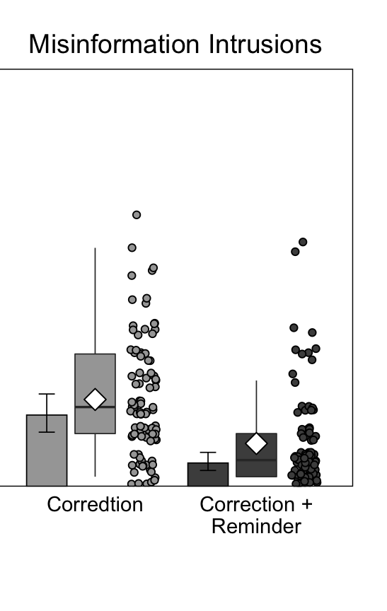

```r
#Visualize list 1 intrusions
l1_intru_all <- ggplot(p1_intrusion_sub_df, aes(x = ItemType, y = prob)) +
                geom_boxplot(aes(fill = ItemType, x = x_box_pos), outlier.size = -1, size = .3, width = .25) +
                geom_point(aes(fill = ItemType, x = x_pnt_pos), shape = 21, size = 1.5,
                           position = position_jitterdodge(jitter.width = .325, jitter.height = .02),
                           color = "black", stroke = .5, alpha = 1, show.legend = FALSE) +
                stat_summary(aes(x = x_box_pos), fun.y = "mean", size = 4, shape = 23, color = "black", fill = "white", geom = "point") +
                geom_bar(data = p1_intrusion_emmeans_df, aes(fill = ItemType, x = ci_point), stat = "identity",
                         width = .25, size = .3, color = "black", position = position_dodge()) +
                geom_errorbar(data = p1_intrusion_emmeans_df, aes(ymin = asymp.LCL, ymax = asymp.UCL, x = ci_point),
                              width = .1, size = .3, position = position_dodge(), color = "black", show.legend = FALSE) +
                scale_fill_manual(values = c("grey65", "grey30")) +
                scale_x_continuous(breaks=seq(1, 2, 1), limits = c(.5, 2.5), labels=c("Corredtion", "Correction +\nReminder"))+
                scale_y_continuous(expand = c(0, 0), limits = c(0, 1.05), breaks = seq(0, 1, .1)) +
                ggtitle("Misinformation Intrusions") +
                xlab("") +
                ylab(NULL) +
                theme(legend.position = "none",
                   legend.key.size = unit(.65, "cm"),
                   legend.key=element_rect(color = "black", size = .1),
                   legend.title=element_blank(),
                   legend.text=element_text(size = 12),
                   strip.background=element_blank(),
                   strip.text.x=element_text(size = 14, color = "black", margin = margin(0, 0, 8, 0)),
                   strip.text.y=element_blank(),
                   axis.ticks.x=element_blank(),
                   axis.ticks.y=element_blank(),
                   axis.text.x=element_text(size=11,color="black"),
                   axis.text.y=element_blank(),
                   axis.title.x=element_text(size=14, margin = margin(8, 0, 0, 0)),
                   axis.title.y=element_text(size=14, margin = margin(0, 8, 0, 0)),
                   plot.margin = unit(c(.25, .25, .25, -.05), "in"),
                   plot.title = element_text(size = 14, color = "black", hjust = .5),
                   panel.background = element_blank(),
                   panel.grid.major = element_blank(),
                   panel.grid.minor = element_blank(),
                   panel.spacing.x = unit(-.01, "in"),
                   panel.border = element_rect(size = .5, fill = NA, color = "black"))
l1_intru_all
```

Combine Correct Facts and Misinformation Intrusions plots

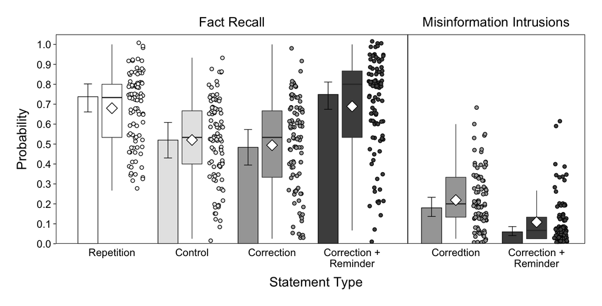

```r
e1_recall_intru <- grid.arrange(l2_recall_all, l1_intru_all, ncol = 2, widths = c(6, 2.85))
```

```r
e1_recall_intru
```

Fit Mixed Effects Model to Belief Ratings for Correct Facts

```r
#gmler for belief ratings for Correct Facts
belief_correct_lmer <- lmer(Belief.RESP ~ ItemType + (1 | Subject) + (1 | Topic), data = subset(cued_recall, P2_Correct == 1))

#Run ANOVA
Anova(belief_correct_lmer)
```

```
## Analysis of Deviance Table (Type II Wald chisquare tests)
##
## Response: Belief.RESP
##           Chisq Df Pr(>Chisq)
## ItemType 50.171  3  7.348e-11 ***
## ---
## Signif. codes:  0 '***' 0.001 '**' 0.01 '*' 0.05 '.' 0.1 ' ' 1
```

```r
#Pairwise comparisons
belief_correct_lmer_emmeans <- emmeans(belief_correct_lmer, list(pairwise ~ ItemType), type = "response")
```

```
## Note: D.f. calculations have been disabled because the number of observations exceeds 3000.
## To enable adjustments, add the argument 'pbkrtest.limit = 3430' (or larger)
## [or, globally, 'set emm_options(pbkrtest.limit = 3430)' or larger];
## but be warned that this may result in large computation time and memory use.
```

```
## Note: D.f. calculations have been disabled because the number of observations exceeds 3000.
## To enable adjustments, add the argument 'lmerTest.limit = 3430' (or larger)
## [or, globally, 'set emm_options(lmerTest.limit = 3430)' or larger];
## but be warned that this may result in large computation time and memory use.
```

```r
belief_correct_lmer_emmeans
```

```
## $`emmeans of ItemType`
##  ItemType   emmean     SE  df asymp.LCL asymp.UCL
##  Control      4.36 0.0966 Inf      4.17      4.55
##  Correction   4.55 0.0973 Inf      4.36      4.74
##  Repetition   4.49 0.0937 Inf      4.31      4.68
##  Retraction   4.76 0.0937 Inf      4.58      4.95
##
## Degrees-of-freedom method: asymptotic
## Confidence level used: 0.95
##
## $`pairwise differences of ItemType`
##  1                       estimate     SE  df z.ratio p.value
##  Control - Correction      -0.193 0.0642 Inf -3.003  0.0142
##  Control - Repetition      -0.135 0.0592 Inf -2.273  0.1043
##  Control - Retraction      -0.404 0.0593 Inf -6.810  <.0001
##  Correction - Repetition    0.058 0.0604 Inf  0.960  0.7722
##  Correction - Retraction   -0.211 0.0601 Inf -3.510  0.0025
##  Repetition - Retraction   -0.269 0.0550 Inf -4.888  <.0001
##
## Degrees-of-freedom method: asymptotic
## P value adjustment: tukey method for comparing a family of 4 estimates
```

```r
#extract estimated probabilities
belief_correct_lmer_emmeans_df <- as_tibble(belief_correct_lmer_emmeans$`emmeans of ItemType`)
belief_correct_lmer_emmeans_df
```

```
## # A tibble: 4 x 6
##   ItemType   emmean     SE    df asymp.LCL asymp.UCL
##   <fct>       <dbl>  <dbl> <dbl>     <dbl>     <dbl>
## 1 Control      4.36 0.0966   Inf      4.17      4.55
## 2 Correction   4.55 0.0973   Inf      4.36      4.74
## 3 Repetition   4.49 0.0937   Inf      4.31      4.68
## 4 Retraction   4.76 0.0937   Inf      4.58      4.95
```

```r
#reorder factor levels
belief_correct_lmer_emmeans_df$ItemType <- factor(belief_correct_lmer_emmeans_df$ItemType, levels = c("Repetition", "Control", "Correction", "Retraction"))

#set x position for model-estimated probabilities and confidence intervals
belief_correct_lmer_emmeans_df$ci_point <- c(1.7, 2.7, 0.7, 3.7)

#add response type variable
belief_correct_lmer_emmeans_df$ResponseType <- "Correct Facts"

belief_correct_lmer_emmeans_df
```

```
## # A tibble: 4 x 8
##   ItemType   emmean     SE    df asymp.LCL asymp.UCL ci_point ResponseType
##   <fct>       <dbl>  <dbl> <dbl>     <dbl>     <dbl>    <dbl> <chr>
## 1 Control      4.36 0.0966   Inf      4.17      4.55      1.7 Correct Facts
## 2 Correction   4.55 0.0973   Inf      4.36      4.74      2.7 Correct Facts
## 3 Repetition   4.49 0.0937   Inf      4.31      4.68      0.7 Correct Facts
## 4 Retraction   4.76 0.0937   Inf      4.58      4.95      3.7 Correct Facts
```

Create Belief Rating for Correct Facts data frame including individual subject means

```r
#data frame to summarize belief ratings for Correct Facts for individual subjects
belief_correct_sub_df <- cued_recall %>%
                         filter(P2_Correct == 1) %>%
                         group_by(Subject, ItemType) %>%
                         summarise(emmean = mean(Belief.RESP)) %>%
                         as_tibble()
```

```r
#reorder factor levels
belief_correct_sub_df$ItemType <- factor(belief_correct_sub_df$ItemType, levels = c("Repetition", "Control", "Correction", "Retraction"))

#set x axis position for box plots
belief_correct_sub_df$x_box_pos <- ifelse(belief_correct_sub_df$ItemType == "Repetition", 1.0,
                                   ifelse(belief_correct_sub_df$ItemType == "Control", 2.0,
                                   ifelse(belief_correct_sub_df$ItemType == "Correction", 3.0,
                                   ifelse(belief_correct_sub_df$ItemType == "Retraction", 4.0, ""))))
#set x axis position for point plots
belief_correct_sub_df$x_pnt_pos <- ifelse(belief_correct_sub_df$ItemType == "Repetition", 1.3,
                                   ifelse(belief_correct_sub_df$ItemType == "Control", 2.3,
                                   ifelse(belief_correct_sub_df$ItemType == "Correction", 3.3,
                                   ifelse(belief_correct_sub_df$ItemType == "Retraction", 4.3, ""))))

#set x axis positions as numeric variables
belief_correct_sub_df$x_box_pos <- as.numeric(belief_correct_sub_df$x_box_pos)
belief_correct_sub_df$x_pnt_pos <- as.numeric(belief_correct_sub_df$x_pnt_pos)

#add response type variable
belief_correct_sub_df$ResponseType <- "Correct Facts"

belief_correct_sub_df
```

```
## # A tibble: 378 x 6
##    Subject ItemType   emmean x_box_pos x_pnt_pos ResponseType
##    <fct>   <fct>       <dbl>     <dbl>     <dbl> <chr>
##  1 101     Control      4.78         2       2.3 Correct Facts
##  2 101     Correction   5.08         3       3.3 Correct Facts
##  3 101     Repetition   4.58         1       1.3 Correct Facts
##  4 101     Retraction   5.31         4       4.3 Correct Facts
##  5 102     Control      5.6          2       2.3 Correct Facts
##  6 102     Correction   5.11         3       3.3 Correct Facts
##  7 102     Repetition   4.91         1       1.3 Correct Facts
##  8 102     Retraction   5.17         4       4.3 Correct Facts
##  9 103     Control      6            2       2.3 Correct Facts
## 10 103     Correction   6            3       3.3 Correct Facts
## # … with 368 more rows
```

Visualize Belief Ratings for Correct Recall

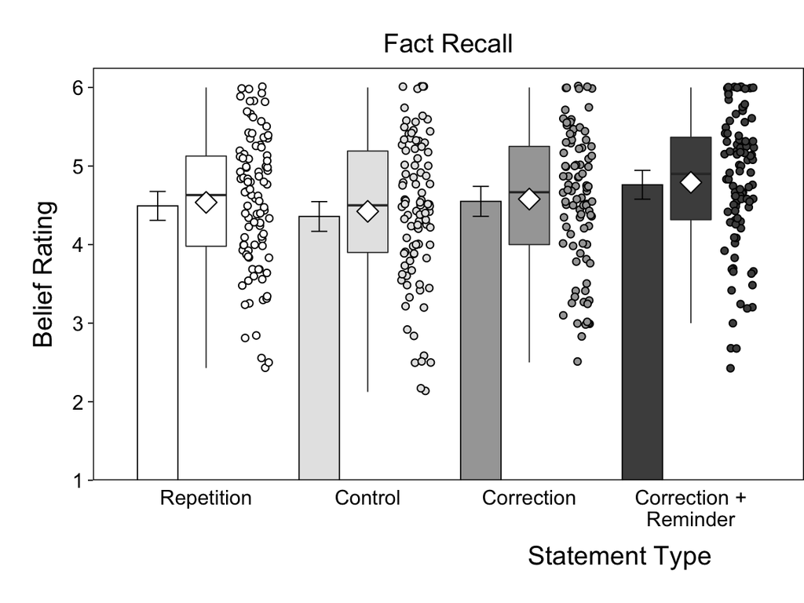

```r
#Visualize belief ratings
belief_cor_p <- ggplot(belief_correct_sub_df, aes(x = ItemType, y = emmean)) +
                geom_boxplot(aes(fill = ItemType, x = x_box_pos), outlier.size = -1, size = .3, width = .25) +
                geom_point(aes(fill = ItemType, x = x_pnt_pos), shape = 21, size = 1.5,
                           position = position_jitterdodge(jitter.width = .55, jitter.height = .02),
                           color = "black", stroke = .5, alpha = 1, show.legend = FALSE) +
                stat_summary(aes(x = x_box_pos), fun.y = "mean", size = 4, shape = 23, color = "black", fill = "white", geom = "point") +
                geom_bar(data = belief_correct_lmer_emmeans_df, aes(fill = ItemType, x = ci_point), stat = "identity",
                         width = .25, size = .3, color = "black", position = position_dodge()) +
                geom_errorbar(data = belief_correct_lmer_emmeans_df, aes(ymin = asymp.LCL, ymax = asymp.UCL, x = ci_point),
                              width = .1, size = .3, position = position_dodge(), color = "black", show.legend = FALSE) +
                coord_cartesian(ylim = c(1, 6.25)) +
                scale_fill_manual(values = c("white", "grey90", "grey65", "grey30")) +
                scale_x_continuous(breaks=seq(1, 4, 1), limits = c(.5, 4.5), labels=c("Repetition", "Control", "Correction", "Correction +\nReminder"))+
                scale_y_continuous(expand = c(0, 0), breaks = seq(1, 6, 1)) +
                ggtitle("Fact Recall") +
                xlab("Statement Type") +
                ylab("Belief Rating") +
                theme(legend.position = "none",
                      legend.key.size = unit(.65, "cm"),
                      legend.key=element_rect(color = "black", size = .1),
                      legend.title=element_blank(),
                      legend.text=element_text(size = 12),
                      strip.background=element_blank(),
                      strip.text.x=element_text(size = 14, color = "black", margin = margin(0, 0, 8, 0)),
                      strip.text.y=element_blank(),
                      axis.ticks.x=element_blank(),
                      axis.ticks.y=element_line(size=.3,color="black"),
                      axis.text.x=element_text(size=11,color="black"),
                      axis.text.y=element_text(size=11,color="black"),
                      axis.title.x=element_text(size=14, margin = margin(8, 0, 0, 0), hjust = .825),
                      axis.title.y=element_text(size=14, margin = margin(0, 8, 0, 0)),
                      plot.margin = unit(c(.25, .00, .25, .25), "in"),
                      plot.title = element_text(size = 14, color = "black", hjust = .5),
                      panel.background = element_blank(),
                      panel.grid.major = element_blank(),
                      panel.grid.minor = element_blank(),
                      panel.spacing.x = unit(-.01, "in"),
                      panel.border = element_rect(size = .5, fill = NA, color = "black"))
belief_cor_p
```

Fit Mixed Effects Model to Belief Ratings for Misinformation Intrusions

```r
#subset Belief responses for Corrections and Retractions
cued_recall_belief_df <- cued_recall %>% filter(ItemType == c("Correction", "Retraction"))

#gmler for belief ratings for Misinformation Intrusions
belief_misinfo_lmer <- lmer(Belief.RESP ~ ItemType + (1 | Subject) + (1 | Topic), data = subset(cued_recall_belief_df, P1_Intrusion == 1))

#Run ANOVA
Anova(belief_misinfo_lmer)
```

```
## Analysis of Deviance Table (Type II Wald chisquare tests)
##
## Response: Belief.RESP
##           Chisq Df Pr(>Chisq)
## ItemType 6.1496  1    0.01314 *
## ---
## Signif. codes:  0 '***' 0.001 '**' 0.01 '*' 0.05 '.' 0.1 ' ' 1
```

```r
#Pairwise comparisons
belief_misinfo_lmer_emmeans <- emmeans(belief_misinfo_lmer, list(pairwise ~ ItemType), type = "response")
belief_misinfo_lmer_emmeans
```

```
## $`emmeans of ItemType`
##  ItemType   emmean    SE    df lower.CL upper.CL
##  Correction   3.95 0.163  76.7     3.62     4.27
##  Retraction   3.39 0.224 158.3     2.95     3.84
##
## Degrees-of-freedom method: kenward-roger
## Confidence level used: 0.95
##
## $`pairwise differences of ItemType`
##  1                       estimate    SE  df t.ratio p.value
##  Correction - Retraction    0.552 0.225 198 2.450   0.0151
##
## Degrees-of-freedom method: kenward-roger
```

```r
#extract estimated probabilities
belief_misinfo_lmer_emmeans_df <- as_tibble(belief_misinfo_lmer_emmeans$`emmeans of ItemType`)
belief_misinfo_lmer_emmeans_df
```

```
## # A tibble: 2 x 6
##   ItemType   emmean    SE    df lower.CL upper.CL
##   <fct>       <dbl> <dbl> <dbl>    <dbl>    <dbl>
## 1 Correction   3.95 0.163  76.7     3.62     4.27
## 2 Retraction   3.39 0.224 158.      2.95     3.84
```

```r
#reorder factor levels
belief_misinfo_lmer_emmeans_df$ItemType <- factor(belief_misinfo_lmer_emmeans_df$ItemType, levels = c("Correction", "Retraction"))

#set x position for model-estimated probabilities and confidence intervals
belief_misinfo_lmer_emmeans_df$ci_point <- c(0.7, 1.7)

belief_misinfo_lmer_emmeans_df
```

```
## # A tibble: 2 x 7
##   ItemType   emmean    SE    df lower.CL upper.CL ci_point
##   <fct>       <dbl> <dbl> <dbl>    <dbl>    <dbl>    <dbl>
## 1 Correction   3.95 0.163  76.7     3.62     4.27      0.7
## 2 Retraction   3.39 0.224 158.      2.95     3.84      1.7
```

Create Belief Rating for Misinformation Intrusions data frame including individual subject means

```r
#data frame to summarize belief ratings for Correct Facts for individual subjects
belief_misinfo_sub_df <- cued_recall %>%
                         filter(P1_Intrusion == 1, ItemType == "Correction" | ItemType == "Retraction") %>%
                         group_by(Subject, ItemType) %>%
                         summarise(emmean = mean(Belief.RESP)) %>%
                         as_tibble()
```

```r
#reorder factor levels
belief_misinfo_sub_df$ItemType <- factor(belief_misinfo_sub_df$ItemType, levels = c("Correction", "Retraction"))

#set x axis position for box plots
belief_misinfo_sub_df$x_box_pos <- ifelse(belief_misinfo_sub_df$ItemType == "Correction", 1.0,
                                   ifelse(belief_misinfo_sub_df$ItemType == "Retraction", 2.0, ""))

#set x axis position for point plots
belief_misinfo_sub_df$x_pnt_pos <- ifelse(belief_misinfo_sub_df$ItemType == "Correction", 1.3,
                                   ifelse(belief_misinfo_sub_df$ItemType == "Retraction", 2.3, ""))

#set x axis position variables as numeric
belief_misinfo_sub_df$x_box_pos <- as.numeric(belief_misinfo_sub_df$x_box_pos)
belief_misinfo_sub_df$x_pnt_pos <- as.numeric(belief_misinfo_sub_df$x_pnt_pos)

#raise means of 1 up a little
belief_misinfo_sub_df$emmean <- ifelse(belief_misinfo_sub_df$emmean == 1, 1.07, belief_misinfo_sub_df$emmean)

belief_misinfo_sub_df
```

```
## # A tibble: 153 x 5
##    Subject ItemType   emmean x_box_pos x_pnt_pos
##    <fct>   <fct>       <dbl>     <dbl>     <dbl>
##  1 101     Correction   3            1       1.3
##  2 102     Correction   5            1       1.3
##  3 102     Retraction   1.5          2       2.3
##  4 103     Correction   6            1       1.3
##  5 104     Correction   3.5          1       1.3
##  6 104     Retraction   2.67         2       2.3
##  7 105     Correction   3.5          1       1.3
##  8 105     Retraction   3            2       2.3
##  9 106     Correction   2            1       1.3
## 10 106     Retraction   2            2       2.3
## # … with 143 more rows
```

Visualize Belief Ratings for Misinformation Intrusions

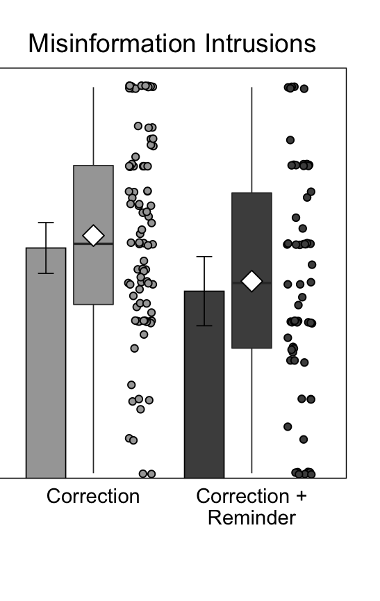

```r
#Visualize belief ratings
belief_int_p <- ggplot(belief_misinfo_sub_df, aes(x = ItemType, y = emmean)) +
                geom_boxplot(aes(fill = ItemType, x = x_box_pos), outlier.size = -1, size =.3, width = .25) +
                geom_point(aes(fill = ItemType, x = x_pnt_pos), shape = 21, size = 1.5,
                           position = position_jitterdodge(jitter.width = .325, jitter.height = .02),
                           color = "black", stroke = .5, alpha = 1, show.legend = FALSE) +
                stat_summary(aes(x = x_box_pos), fun.y = "mean", size = 4, shape = 23, color = "black", fill = "white", geom = "point") +
                geom_bar(data = belief_misinfo_lmer_emmeans_df, aes(fill = ItemType, x = ci_point), stat = "identity",
                         width = .25, size = .3, color = "black", position = position_dodge()) +
                geom_errorbar(data = belief_misinfo_lmer_emmeans_df, aes(ymin = lower.CL, ymax = upper.CL, x = ci_point),
                              width = .1, size = .3, position = position_dodge(), color = "black", show.legend = FALSE) +
                coord_cartesian(ylim = c(1, 6.25)) +
                scale_fill_manual(values = c("grey65", "grey30")) +
                scale_x_continuous(breaks=seq(1, 2, 1), limits = c(.5, 2.5), labels=c("Correction", "Correction +\nReminder"))+
                scale_y_continuous(expand = c(0, 0), breaks = seq(1, 6, 1)) +
                ggtitle("Misinformation Intrusions") +
                xlab("") +
                ylab(NULL) +
                theme(legend.position = "none",
                      legend.key.size = unit(.65, "cm"),
                      legend.key=element_rect(color = "black", size = .1),
                      legend.title=element_blank(),
                      legend.text=element_text(size = 12),
                      strip.background=element_blank(),
                      strip.text.x=element_text(size = 14, color = "black", margin = margin(0, 0, 8, 0)),
                      strip.text.y=element_blank(),
                      axis.ticks.x=element_blank(),
                      axis.ticks.y=element_blank(),
                      axis.text.x=element_text(size = 11,color="black"),
                      axis.text.y=element_blank(),
                      axis.title.x=element_text(size = 14, margin = margin(8, 0, 0, 0)),
                      axis.title.y=element_text(size = 14, margin = margin(0, 8, 0, 0)),
                      plot.margin = unit(c(.25, .25, .25, -.05), "in"),
                      plot.title = element_text(size = 14, color = "black", hjust = .5),
                      panel.background = element_blank(),
                      panel.grid.major = element_blank(),
                      panel.grid.minor = element_blank(),
                      panel.spacing.x = unit(-.01, "in"),
                      panel.border = element_rect(size = .5, fill = NA, color = "black"))
belief_int_p
```

Combine Belief in Correct Facts and Misinformation Intrusions plots

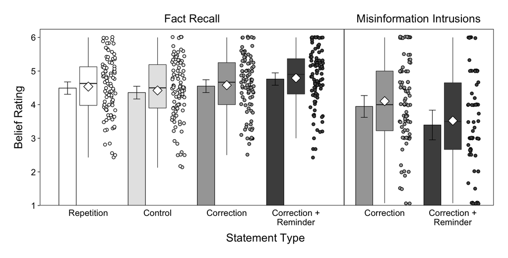

```r
e1_belief_recall_intru <- grid.arrange(belief_cor_p, belief_int_p, ncol = 2, widths = c(6, 2.85))
```

```r
e1_belief_recall_intru
```

Combine Recall and Belief Plots

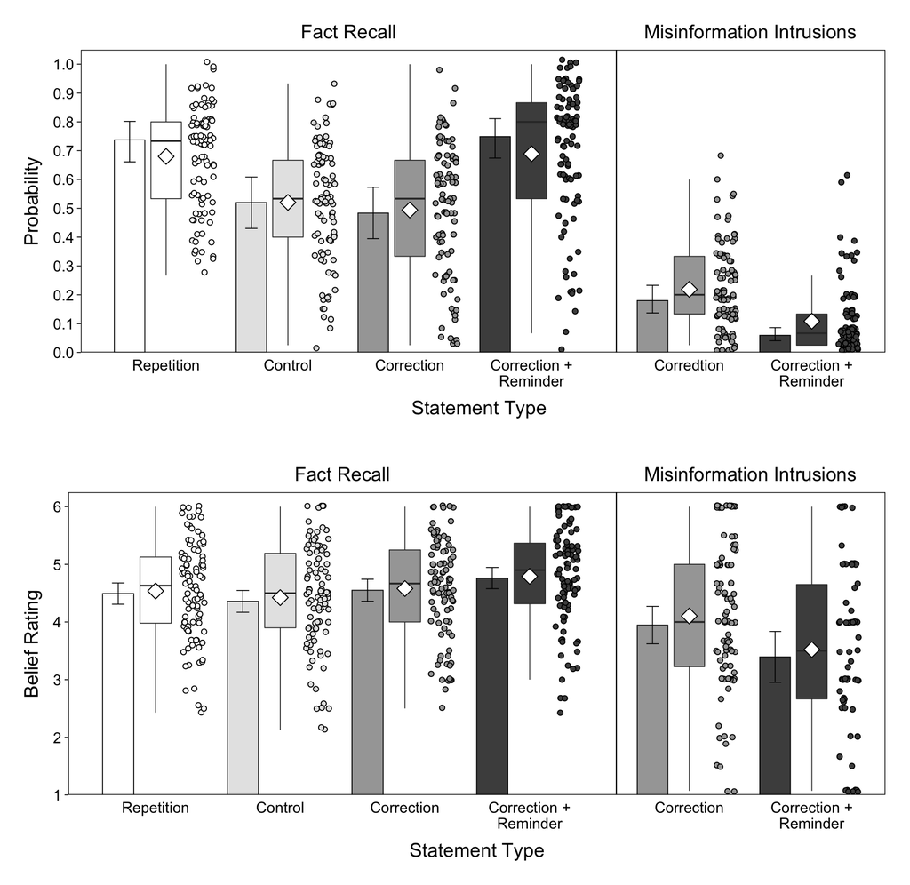

```r
e1_recall_and_belief_plots <- grid.arrange(e1_recall_intru, e1_belief_recall_intru, nrow = 2)
```

```r
e1_recall_and_belief_plots
```

```r
ggsave("Fig_1_E1_Recall_and_Beliefs.pdf", plot = e1_recall_and_belief_plots, width = 8.85, height = 9, units = "in", dpi = 320, device = "pdf")
ggsave("Fig_1_E1_Recall_and_Beliefs.png", plot = e1_recall_and_belief_plots, width = 8.85, height = 9, units = "in", dpi = 320, device = "png")
```

Fit Mixed Effects Models to Change Classification Probabilities

```r
#gmler for misinformation recollection data
misinfo_rec_glmer <- glmer(Misinformation_Recollected ~ ItemType + (1 | Subject) + (1 | Topic),
                           family = binomial, data = cued_recall, subset = ItemType == c("Correction", "Retraction"))

#Run ANOVA for misinformation recollection for all item types
Anova(misinfo_rec_glmer)
```

```
## Analysis of Deviance Table (Type II Wald chisquare tests)
##
## Response: Misinformation_Recollected
##           Chisq Df Pr(>Chisq)
## ItemType 64.061  1  1.207e-15 ***
## ---
## Signif. codes:  0 '***' 0.001 '**' 0.01 '*' 0.05 '.' 0.1 ' ' 1
```

```r
#Pairwise comparisons for misinformation recollection for all items types
misinfo_rec_emmeans <- emmeans(misinfo_rec_glmer, list(pairwise ~ ItemType), type = "response")
misinfo_rec_emmeans
```

```
## $`emmeans of ItemType`
##  ItemType    prob     SE  df asymp.LCL asymp.UCL
##  Correction 0.307 0.0444 Inf     0.227      0.40
##  Retraction 0.565 0.0506 Inf     0.465      0.66
##
## Confidence level used: 0.95
## Intervals are back-transformed from the logit scale
##
## $`pairwise differences of ItemType`
##  1                       odds.ratio     SE  df z.ratio p.value
##  Correction / Retraction      0.341 0.0458 Inf -8.004  <.0001
##
## Tests are performed on the log odds ratio scale
```

```r
#extract estimated probabilities
misinfo_rec_emmeans_df <- as_tibble(misinfo_rec_emmeans$`emmeans of ItemType`)
misinfo_rec_emmeans_df$Classification <- "Misinformation Recollected"
misinfo_rec_emmeans_df
```

```
## # A tibble: 2 x 7
##   ItemType    prob     SE    df asymp.LCL asymp.UCL Classification
##   <fct>      <dbl>  <dbl> <dbl>     <dbl>     <dbl> <chr>
## 1 Correction 0.307 0.0444   Inf     0.227     0.400 Misinformation Recollected
## 2 Retraction 0.565 0.0506   Inf     0.465     0.660 Misinformation Recollected
```

```r
#gmler for correction remembering data
correction_rem_glmer <- glmer(Correction_Remembered ~ ItemType + (1 | Subject) + (1 | Topic),
                        family = binomial, data = cued_recall, subset = ItemType == c("Correction", "Retraction"))

#Run ANOVA for misinformation recollection for all item types
Anova(correction_rem_glmer)
```

```
## Analysis of Deviance Table (Type II Wald chisquare tests)
##
## Response: Correction_Remembered
##           Chisq Df Pr(>Chisq)
## ItemType 1.1439  1     0.2848
```

```r
#Pairwise comparisons for misinformation recollection for all items types
correction_rem_emmeans <- emmeans(correction_rem_glmer, list(pairwise ~ ItemType), type = "response")
correction_rem_emmeans
```

```
## $`emmeans of ItemType`
##  ItemType    prob     SE  df asymp.LCL asymp.UCL
##  Correction 0.146 0.0195 Inf     0.112     0.189
##  Retraction 0.166 0.0212 Inf     0.128     0.212
##
## Confidence level used: 0.95
## Intervals are back-transformed from the logit scale
##
## $`pairwise differences of ItemType`
##  1                       odds.ratio    SE  df z.ratio p.value
##  Correction / Retraction       0.86 0.121 Inf -1.070  0.2848
##
## Tests are performed on the log odds ratio scale
```

```r
#extract estimated probabilities
correction_rem_emmeans_df <- as_tibble(correction_rem_emmeans$`emmeans of ItemType`)
correction_rem_emmeans_df$Classification <- "Correction Remembered"
correction_rem_emmeans_df
```

```
## # A tibble: 2 x 7
##   ItemType    prob     SE    df asymp.LCL asymp.UCL Classification
##   <fct>      <dbl>  <dbl> <dbl>     <dbl>     <dbl> <chr>
## 1 Correction 0.146 0.0195   Inf     0.112     0.189 Correction Remembered
## 2 Retraction 0.166 0.0212   Inf     0.128     0.212 Correction Remembered
```

```r
#create data frame that combines model estimates for change classifications
change_class_emmeans_df <- bind_rows(misinfo_rec_emmeans_df, correction_rem_emmeans_df)

#set x position for model-estimated probabilities and confidence intervals
change_class_emmeans_df$ci_point <- c(0.7, 1.7, 0.7, 1.7)

#reorder factor levels
change_class_emmeans_df$Classification <- factor(change_class_emmeans_df$Classification, levels = c("Misinformation Recollected", "Correction Remembered"))

change_class_emmeans_df
```

```
## # A tibble: 4 x 8
##   ItemType   prob     SE    df asymp.LCL asymp.UCL Classification       ci_point
##   <fct>     <dbl>  <dbl> <dbl>     <dbl>     <dbl> <fct>                   <dbl>
## 1 Correcti… 0.307 0.0444   Inf     0.227     0.400 Misinformation Reco…      0.7
## 2 Retracti… 0.565 0.0506   Inf     0.465     0.660 Misinformation Reco…      1.7
## 3 Correcti… 0.146 0.0195   Inf     0.112     0.189 Correction Remember…      0.7
## 4 Retracti… 0.166 0.0212   Inf     0.128     0.212 Correction Remember…      1.7
```

Create Change Classification data frame including individual subject means

```r
#data frame to summarize misinformation recollection for individual subjects
misinfo_rec_sub_df <- cued_recall %>%
                      filter(ItemType == "Correction" | ItemType == "Retraction") %>%
                      group_by(Subject, ItemType) %>%
                      summarise(prob = mean(Misinformation_Recollected))
misinfo_rec_sub_df$Classification <- "Misinformation Recollected"

misinfo_rec_sub_df
```

```
## # A tibble: 192 x 4
## # Groups:   Subject [96]
##    Subject ItemType     prob Classification
##    <fct>   <chr>       <dbl> <chr>
##  1 101     Correction 0.533  Misinformation Recollected
##  2 101     Retraction 0.733  Misinformation Recollected
##  3 102     Correction 0.133  Misinformation Recollected
##  4 102     Retraction 0.467  Misinformation Recollected
##  5 103     Correction 0.267  Misinformation Recollected
##  6 103     Retraction 0.467  Misinformation Recollected
##  7 104     Correction 0.0667 Misinformation Recollected
##  8 104     Retraction 0      Misinformation Recollected
##  9 105     Correction 0.133  Misinformation Recollected
## 10 105     Retraction 0.6    Misinformation Recollected
## # … with 182 more rows
```

```r
#data frame to summarize correction remembering for individual subjects
correct_rem_sub_df <- cued_recall %>%
                      filter(ItemType == "Correction" | ItemType == "Retraction") %>%
                      group_by(Subject, ItemType) %>%
                      summarise(prob = mean(Correction_Remembered))
correct_rem_sub_df$Classification <- "Correction Remembered"

correct_rem_sub_df
```

```
## # A tibble: 192 x 4
## # Groups:   Subject [96]
##    Subject ItemType    prob Classification
##    <fct>   <chr>      <dbl> <chr>
##  1 101     Correction 0.133 Correction Remembered
##  2 101     Retraction 0.2   Correction Remembered
##  3 102     Correction 0.267 Correction Remembered
##  4 102     Retraction 0.267 Correction Remembered
##  5 103     Correction 0.133 Correction Remembered
##  6 103     Retraction 0.133 Correction Remembered
##  7 104     Correction 0.4   Correction Remembered
##  8 104     Retraction 0.667 Correction Remembered
##  9 105     Correction 0.4   Correction Remembered
## 10 105     Retraction 0.267 Correction Remembered
## # … with 182 more rows
```

```r
#merge data frames
correction_class_sub_df <- bind_rows(misinfo_rec_sub_df, correct_rem_sub_df)

#set x axis position for box plots
correction_class_sub_df$x_box_pos <- if_else(correction_class_sub_df$ItemType == "Correction", "1",
                                     if_else(correction_class_sub_df$ItemType == "Retraction", "2", "na")) %>% as.numeric()


#set x axis position for point plots
correction_class_sub_df$x_pnt_pos <- if_else(correction_class_sub_df$ItemType == "Correction", "1.3",
                                     if_else(correction_class_sub_df$ItemType == "Retraction", "2.3", "na")) %>% as.numeric()

#reorder factor levels
correction_class_sub_df$Classification <- factor(correction_class_sub_df$Classification, levels = c("Misinformation Recollected", "Correction Remembered"))

#move zero probs up
correction_class_sub_df$prob <- ifelse(correction_class_sub_df$prob == 0, .025, correction_class_sub_df$prob)

correction_class_sub_df
```

```
## # A tibble: 384 x 6
## # Groups:   Subject [96]
##    Subject ItemType     prob Classification             x_box_pos x_pnt_pos
##    <fct>   <chr>       <dbl> <fct>                          <dbl>     <dbl>
##  1 101     Correction 0.533  Misinformation Recollected         1       1.3
##  2 101     Retraction 0.733  Misinformation Recollected         2       2.3
##  3 102     Correction 0.133  Misinformation Recollected         1       1.3
##  4 102     Retraction 0.467  Misinformation Recollected         2       2.3
##  5 103     Correction 0.267  Misinformation Recollected         1       1.3
##  6 103     Retraction 0.467  Misinformation Recollected         2       2.3
##  7 104     Correction 0.0667 Misinformation Recollected         1       1.3
##  8 104     Retraction 0.025  Misinformation Recollected         2       2.3
##  9 105     Correction 0.133  Misinformation Recollected         1       1.3
## 10 105     Retraction 0.6    Misinformation Recollected         2       2.3
## # … with 374 more rows
```

Visualize Correction Classifications

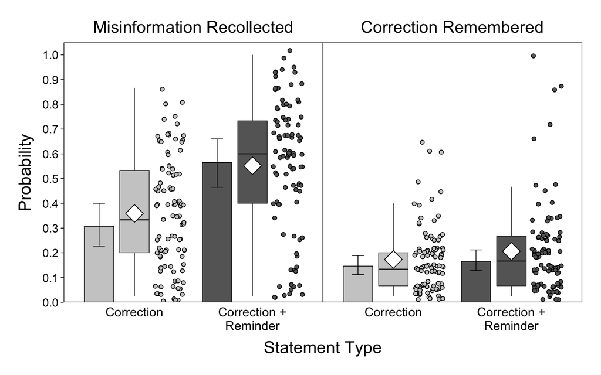

```r
correction_all <- ggplot(correction_class_sub_df, aes(x = ItemType, y = prob)) +
                  geom_boxplot(aes(fill = ItemType, x = x_box_pos), outlier.size = -1, size =.3, width = .25) +
                  geom_point(aes(fill = ItemType, x = x_pnt_pos), shape = 21, size = 1.5,
                             position = position_jitterdodge(jitter.width = .25, jitter.height = .02),
                             color = "black", stroke = .5, alpha = 1, show.legend = FALSE) +
                  stat_summary(aes(x = x_box_pos), fun.y = "mean", size = 6, shape = 23, color = "black", fill = "white", geom = "point") +
                  geom_bar(data = change_class_emmeans_df, aes(fill = ItemType, x = ci_point), stat = "identity",
                           width = .25, size = .3, color = "black", position = position_dodge()) +
                  geom_errorbar(data = change_class_emmeans_df, aes(ymin = asymp.LCL, ymax = asymp.UCL, x = ci_point),
                                width = .1, size = .3, position = position_dodge(), color = "black", show.legend = FALSE) +
                  scale_fill_grey(start = .8, end = .4) +
                  facet_grid(. ~ Classification) +
                  scale_x_continuous(breaks=seq(1, 2, 1), limits = c(.5, 2.5), labels=c("Correction", "Correction +\nReminder"))+
                  scale_y_continuous(expand = c(0, 0), limits = c(0, 1.05), breaks = seq(0, 1, .1)) +
                  xlab("Statement Type") +
                  ylab("Probability") +
                  theme(legend.position = "none",
                        legend.key.size = unit(.65, "cm"),
                        legend.key=element_rect(color = "black", size = .1),
                        legend.title=element_blank(),
                        legend.text=element_text(size = 12),
                        strip.background=element_blank(),
                        strip.text.x=element_text(size = 16, color = "black", margin = margin(0, 0, 8, 0)),
                        strip.text.y=element_blank(),
                        axis.ticks.x=element_blank(),
                        axis.ticks.y=element_line(size=.3,color="black"),
                        axis.text.x=element_text(size=12,color="black"),
                        axis.text.y=element_text(size=11,color="black"),
                        axis.title.x=element_text(size=16, margin = margin(8, 0, 0, 0)),
                        axis.title.y=element_text(size=16, margin = margin(0, 8, 0, 0)),
                        plot.margin = unit(c(.25, .25, .25, .25), "in"),
                        plot.title = element_text(size = 16, color = "black", hjust = .18),
                        panel.background = element_blank(),
                        panel.grid.major = element_blank(),
                        panel.grid.minor = element_blank(),
                        panel.spacing.x = unit(-.01, "in"),
                        panel.border = element_rect(size = .5, fill = NA, color = "black"))
correction_all
```

```r
ggsave("Fig_2_E1_Change_Classifications.pdf", plot = correction_all, width = 8, height = 5, units = "in", dpi = 320)
ggsave("Fig_2_E1_Change_Classifications.png", plot = correction_all, width = 8, height = 5, units = "in", dpi = 320)
```

Fit Mixed Effects Model to List 2 Recall Data Conditionalized on Change Classifications

```r
#glmer for list 2 recall data
p2_recall_cond_glmer <- glmer(P2_Correct ~ ItemType * Correction_Class + (1 | Subject) + (1 | Topic), family = binomial, data = subset(cued_recall, ItemType == c("Correction", "Retraction")))

#Run ANOVA
Anova(p2_recall_cond_glmer)
```

```
## Analysis of Deviance Table (Type II Wald chisquare tests)
##
## Response: P2_Correct
##                              Chisq Df Pr(>Chisq)
## ItemType                   14.0941  1  0.0001739 ***
## Correction_Class          283.7315  2  < 2.2e-16 ***
## ItemType:Correction_Class   0.5312  2  0.7667611
## ---
## Signif. codes:  0 '***' 0.001 '**' 0.01 '*' 0.05 '.' 0.1 ' ' 1
```

```r
#Pairwise comparisons
p2_recall_cond_emmeans <- emmeans(p2_recall_cond_glmer, list(pairwise ~ ItemType,
                                                             pairwise ~ Correction_Class,
                                                             pairwise ~ Correction_Class | ItemType), type = "response")
```

```
## NOTE: Results may be misleading due to involvement in interactions
## NOTE: Results may be misleading due to involvement in interactions
```

```r
p2_recall_cond_emmeans
```

```
## $`emmeans of ItemType`
##  ItemType    prob     SE  df asymp.LCL asymp.UCL
##  Correction 0.557 0.0385 Inf     0.481     0.631
##  Retraction 0.687 0.0343 Inf     0.616     0.750
##
## Results are averaged over the levels of: Correction_Class
## Confidence level used: 0.95
## Intervals are back-transformed from the logit scale
##
## $`pairwise differences of ItemType`
##  1                       odds.ratio     SE  df z.ratio p.value
##  Correction / Retraction      0.574 0.0872 Inf -3.655  0.0003
##
## Results are averaged over the levels of: Correction_Class
## Tests are performed on the log odds ratio scale
##
## $`emmeans of Correction_Class`
##  Correction_Class            prob     SE  df asymp.LCL asymp.UCL
##  Correction Not Remembered  0.256 0.0325 Inf     0.198     0.325
##  Correction Remembered      0.569 0.0456 Inf     0.479     0.656
##  Misinformation Recollected 0.909 0.0153 Inf     0.875     0.935
##
## Results are averaged over the levels of: ItemType
## Confidence level used: 0.95
## Intervals are back-transformed from the logit scale
##
## $`pairwise differences of Correction_Class`
##  1                                                      odds.ratio      SE  df
##  Correction Not Remembered / Correction Remembered          0.2606 0.05135 Inf
##  Correction Not Remembered / Misinformation Recollected     0.0344 0.00693 Inf
##  Correction Remembered / Misinformation Recollected         0.1318 0.02729 Inf
##  z.ratio p.value
##   -6.825 <.0001
##  -16.700 <.0001
##   -9.788 <.0001
##
## Results are averaged over the levels of: ItemType
## P value adjustment: tukey method for comparing a family of 3 estimates
## Tests are performed on the log odds ratio scale
##
```

[output cut: 24 more lines]

```
##  -13.053 <.0001
##   -6.922 <.0001
##
## ItemType = Retraction:
##  2                                                      odds.ratio      SE  df
##  Correction Not Remembered / Correction Remembered          0.2941 0.08259 Inf
##  Correction Not Remembered / Misinformation Recollected     0.0383 0.01071 Inf
##  Correction Remembered / Misinformation Recollected         0.1304 0.03624 Inf
##  z.ratio p.value
##   -4.358 <.0001
##  -11.676 <.0001
##   -7.330 <.0001
##
## P value adjustment: tukey method for comparing a family of 3 estimates
## Tests are performed on the log odds ratio scale
```

```r
#extract estimated probabilities
p2_recall_cond_emmeans_df <- as_tibble(p2_recall_cond_emmeans$`emmeans of Correction_Class | ItemType`)
p2_recall_cond_emmeans_df
```

```
## # A tibble: 6 x 7
##   Correction_Class           ItemType    prob     SE    df asymp.LCL asymp.UCL
##   <fct>                      <fct>      <dbl>  <dbl> <dbl>     <dbl>     <dbl>
## 1 Correction Not Remembered  Correction 0.195 0.0306   Inf     0.142     0.262
## 2 Correction Remembered      Correction 0.511 0.0588   Inf     0.397     0.624
## 3 Misinformation Recollected Correction 0.887 0.0235   Inf     0.832     0.926
## 4 Correction Not Remembered  Retraction 0.329 0.0497   Inf     0.240     0.433
## 5 Correction Remembered      Retraction 0.626 0.0537   Inf     0.516     0.724
## 6 Misinformation Recollected Retraction 0.928 0.0152   Inf     0.892     0.952
```

Create Data Frame for Bubble Plots of Conditional Analyses of Correct Recall

```r
#compute overall counts and proportions for each item type
plot_df <- cued_recall %>%
           group_by(ItemType) %>%
           filter(ItemType == "Correction" | ItemType == "Retraction") %>%
           summarise(n = length(P2_Correct)) %>%
           mutate(prop = 1)
           plot_df$Correction_Class = "All"
plot_df
```

```
## # A tibble: 2 x 4
##   ItemType       n  prop Correction_Class
##   <chr>      <int> <dbl> <chr>
## 1 Correction  1440     1 All
## 2 Retraction  1440     1 All
```

```r
#compute model estimates probabilities of overall correct recall
plot_df_boot <- p2_recall_emmeans_df %>%
                filter(ItemType == "Correction" | ItemType == "Retraction") %>%
                dplyr::select(-SE, -df, -ci_point)
plot_df_boot
```

```
## # A tibble: 2 x 5
##   ItemType    prob asymp.LCL asymp.UCL ResponseType
##   <fct>      <dbl>     <dbl>     <dbl> <chr>
## 1 Correction 0.483     0.395     0.573 Correct Facts
## 2 Retraction 0.749     0.674     0.811 Correct Facts
```

```r
#merge data frames for overall correct recall
plot_df_uncond <- merge(plot_df, plot_df_boot)

plot_df_uncond
```

```
##     ItemType    n prop Correction_Class      prob asymp.LCL asymp.UCL
## 1 Correction 1440    1              All 0.4833279 0.3946778 0.5730399
## 2 Retraction 1440    1              All 0.7489270 0.6742974 0.8112433
##    ResponseType
## 1 Correct Facts
## 2 Correct Facts
```

```r
#Compute counts and proportions for corrections conditionalized change classifications at test
plot_df_cond <- cued_recall %>%
                filter(ItemType == "Correction" | ItemType == "Retraction") %>%
                group_by(ItemType, Correction_Class) %>%
                summarise(n = length(P2_Correct)) %>%
                mutate(prop = n / sum(n))
plot_df_cond
```

```
## # A tibble: 6 x 4
## # Groups:   ItemType [2]
##   ItemType   Correction_Class               n  prop
##   <chr>      <chr>                      <int> <dbl>
## 1 Correction Correction Not Remembered    681 0.473
## 2 Correction Correction Remembered        245 0.170
## 3 Correction Misinformation Recollected   514 0.357
## 4 Retraction Correction Not Remembered    354 0.246
## 5 Retraction Correction Remembered        293 0.203
## 6 Retraction Misinformation Recollected   793 0.551
```

```r
plot_df_cond_boot <- p2_recall_cond_emmeans_df %>%
                     dplyr::select(-SE, -df)
plot_df_cond_boot
```

```
## # A tibble: 6 x 5
##   Correction_Class           ItemType    prob asymp.LCL asymp.UCL
##   <fct>                      <fct>      <dbl>     <dbl>     <dbl>
## 1 Correction Not Remembered  Correction 0.195     0.142     0.262
## 2 Correction Remembered      Correction 0.511     0.397     0.624
## 3 Misinformation Recollected Correction 0.887     0.832     0.926
## 4 Correction Not Remembered  Retraction 0.329     0.240     0.433
## 5 Correction Remembered      Retraction 0.626     0.516     0.724
## 6 Misinformation Recollected Retraction 0.928     0.892     0.952
```

```r
#merge data frames for conditional correct recall
plot_df_cond <- merge(plot_df_cond, plot_df_cond_boot)

plot_df_cond
```

```
##     ItemType           Correction_Class   n      prop      prob asymp.LCL
## 1 Correction  Correction Not Remembered 681 0.4729167 0.1946428 0.1415778
## 2 Correction      Correction Remembered 245 0.1701389 0.5112757 0.3974353
## 3 Correction Misinformation Recollected 514 0.3569444 0.8870518 0.8322545
## 4 Retraction  Correction Not Remembered 354 0.2458333 0.3294096 0.2401757
## 5 Retraction      Correction Remembered 293 0.2034722 0.6255335 0.5159227
## 6 Retraction Misinformation Recollected 793 0.5506944 0.9275912 0.8916609
##   asymp.UCL
## 1 0.2615376
## 2 0.6239584
## 3 0.9255498
## 4 0.4329079
## 5 0.7236206
## 6 0.9522435
```

```r
#change conditional labels for item types in conditional recall
plot_df_cond$ItemType <- ifelse(plot_df_cond$ItemType == "Correction", "Correction (Conditional)", "Retraction (Conditional)")

plot_df_cond
```

```
##                   ItemType           Correction_Class   n      prop      prob
## 1 Correction (Conditional)  Correction Not Remembered 681 0.4729167 0.1946428
## 2 Correction (Conditional)      Correction Remembered 245 0.1701389 0.5112757
## 3 Correction (Conditional) Misinformation Recollected 514 0.3569444 0.8870518
## 4 Retraction (Conditional)  Correction Not Remembered 354 0.2458333 0.3294096
## 5 Retraction (Conditional)      Correction Remembered 293 0.2034722 0.6255335
## 6 Retraction (Conditional) Misinformation Recollected 793 0.5506944 0.9275912
##   asymp.LCL asymp.UCL
## 1 0.1415778 0.2615376
## 2 0.3974353 0.6239584
## 3 0.8322545 0.9255498
## 4 0.2401757 0.4329079
## 5 0.5159227 0.7236206
## 6 0.8916609 0.9522435
```

```r
#Bind data frames
P2_recall_bubble_df <- bind_rows(plot_df_uncond, plot_df_cond)

#reorder factor levels
P2_recall_bubble_df$ItemType <- factor(P2_recall_bubble_df$ItemType, levels = c("Correction", "Correction (Conditional)", "Retraction", "Retraction (Conditional)"))

#create variable for response type
P2_recall_bubble_df$ResponseType <- "Fact Recall"

#set x position for bubbles
P2_recall_bubble_df$x_pos <- c(1, 3, 2, 2, 2, 4, 4, 4)

P2_recall_bubble_df
```

```
##                   ItemType    n      prop           Correction_Class      prob
## 1               Correction 1440 1.0000000                        All 0.4833279
## 2               Retraction 1440 1.0000000                        All 0.7489270
## 3 Correction (Conditional)  681 0.4729167  Correction Not Remembered 0.1946428
## 4 Correction (Conditional)  245 0.1701389      Correction Remembered 0.5112757
## 5 Correction (Conditional)  514 0.3569444 Misinformation Recollected 0.8870518
## 6 Retraction (Conditional)  354 0.2458333  Correction Not Remembered 0.3294096
## 7 Retraction (Conditional)  293 0.2034722      Correction Remembered 0.6255335
## 8 Retraction (Conditional)  793 0.5506944 Misinformation Recollected 0.9275912
##   asymp.LCL asymp.UCL ResponseType x_pos
## 1 0.3946778 0.5730399  Fact Recall     1
## 2 0.6742974 0.8112433  Fact Recall     3
## 3 0.1415778 0.2615376  Fact Recall     2
## 4 0.3974353 0.6239584  Fact Recall     2
## 5 0.8322545 0.9255498  Fact Recall     2
## 6 0.2401757 0.4329079  Fact Recall     4
## 7 0.5159227 0.7236206  Fact Recall     4
## 8 0.8916609 0.9522435  Fact Recall     4
```

Fit Mixed Effects Model to Misinformation Intrusions Data Conditionalized on Change Classifications

```r
#gmler for list 1 intrusion data
p1_intrusion_cond_glmer <- glmer(P1_Intrusion ~ ItemType * Correction_Class + (1 | Subject) + (1 | Topic), family = binomial, data = subset(cued_recall, ItemType == c("Correction", "Retraction")))

#Run ANOVA
Anova(p1_intrusion_cond_glmer)
```

```
## Analysis of Deviance Table (Type II Wald chisquare tests)
##
## Response: P1_Intrusion
##                              Chisq Df Pr(>Chisq)
## ItemType                   18.4800  1  1.717e-05 ***
## Correction_Class          113.9340  2  < 2.2e-16 ***
## ItemType:Correction_Class   0.9567  2     0.6198
## ---
## Signif. codes:  0 '***' 0.001 '**' 0.01 '*' 0.05 '.' 0.1 ' ' 1
```

```r
#Pairwise comparisons
p1_intrusion_cond_emmeans <- emmeans(p1_intrusion_cond_glmer, list(pairwise ~ ItemType,
                                                                   pairwise ~ Correction_Class,
                                                                   pairwise ~ Correction_Class | ItemType), type = "response")
```

```
## NOTE: Results may be misleading due to involvement in interactions
## NOTE: Results may be misleading due to involvement in interactions
```

```r
p1_intrusion_cond_emmeans
```

```
## $`emmeans of ItemType`
##  ItemType    prob     SE  df asymp.LCL asymp.UCL
##  Correction 0.115 0.0218 Inf    0.0788    0.1651
##  Retraction 0.059 0.0131 Inf    0.0381    0.0904
##
## Results are averaged over the levels of: Correction_Class
## Confidence level used: 0.95
## Intervals are back-transformed from the logit scale
##
## $`pairwise differences of ItemType`
##  1                       odds.ratio    SE  df z.ratio p.value
##  Correction / Retraction       2.07 0.477 Inf 3.168   0.0015
##
## Results are averaged over the levels of: Correction_Class
## Tests are performed on the log odds ratio scale
##
## $`emmeans of Correction_Class`
##  Correction_Class             prob     SE  df asymp.LCL asymp.UCL
##  Correction Not Remembered  0.2648 0.0373 Inf   0.19838    0.3439
##  Correction Remembered      0.1412 0.0291 Inf   0.09311    0.2085
##  Misinformation Recollected 0.0123 0.0040 Inf   0.00648    0.0232
##
## Results are averaged over the levels of: ItemType
## Confidence level used: 0.95
## Intervals are back-transformed from the logit scale
##
## $`pairwise differences of Correction_Class`
##  1                                                      odds.ratio    SE  df
##  Correction Not Remembered / Correction Remembered            2.19 0.503 Inf
##  Correction Not Remembered / Misinformation Recollected      28.97 9.333 Inf
##  Correction Remembered / Misinformation Recollected          13.23 4.523 Inf
##  z.ratio p.value
##   3.412  0.0019
##  10.450  <.0001
##   7.553  <.0001
##
## Results are averaged over the levels of: ItemType
## P value adjustment: tukey method for comparing a family of 3 estimates
## Tests are performed on the log odds ratio scale
##
```

[output cut: 24 more lines]

```
##  8.585   <.0001
##  5.710   <.0001
##
## ItemType = Retraction:
##  2                                                      odds.ratio     SE  df
##  Correction Not Remembered / Correction Remembered            1.82  0.630 Inf
##  Correction Not Remembered / Misinformation Recollected      23.60 10.807 Inf
##  Correction Remembered / Misinformation Recollected          12.96  6.278 Inf
##  z.ratio p.value
##  1.731   0.1938
##  6.905   <.0001
##  5.291   <.0001
##
## P value adjustment: tukey method for comparing a family of 3 estimates
## Tests are performed on the log odds ratio scale
```

```r
#extract estimated probabilities
p1_intrusion_cond_emmeans_df <- as_tibble(p1_intrusion_cond_emmeans$`emmeans of Correction_Class | ItemType`)

p1_intrusion_cond_emmeans_df
```

```
## # A tibble: 6 x 7
##   Correction_Class           ItemType     prob      SE    df asymp.LCL asymp.UCL
##   <fct>                      <fct>       <dbl>   <dbl> <dbl>     <dbl>     <dbl>
## 1 Correction Not Remembered  Correcti… 0.371   0.0454    Inf   0.287      0.464
## 2 Correction Remembered      Correcti… 0.183   0.0429    Inf   0.113      0.282
## 3 Misinformation Recollected Correcti… 0.0163  0.00666   Inf   0.00732    0.0361
## 4 Correction Not Remembered  Retracti… 0.180   0.0384    Inf   0.117      0.268
## 5 Correction Remembered      Retracti… 0.108   0.0300    Inf   0.0614     0.182
## 6 Misinformation Recollected Retracti… 0.00922 0.00397   Inf   0.00396    0.0213
```

Create Data Frame for Bubble Plots of Conditional Analyses of Misinformation Intrusions

```r
#compute overall counts and proportions for each item type
plot_df <- cued_recall %>%
           group_by(ItemType) %>%
           filter(ItemType == "Correction" | ItemType == "Retraction") %>%
           summarise(n = length(P1_Intrusion)) %>%
           mutate(prop = 1)
           plot_df$Correction_Class = "All"
plot_df
```

```
## # A tibble: 2 x 4
##   ItemType       n  prop Correction_Class
##   <chr>      <int> <dbl> <chr>
## 1 Correction  1440     1 All
## 2 Retraction  1440     1 All
```

```r
#compute model estimates probabilities of overall Misinformation Intrusions
plot_df_boot <- p1_intrusion_emmeans_df %>%
                dplyr::select(-SE, -df, -ci_point)
plot_df_boot
```

```
## # A tibble: 2 x 5
##   ItemType     prob asymp.LCL asymp.UCL ResponseType
##   <fct>       <dbl>     <dbl>     <dbl> <chr>
## 1 Correction 0.180     0.137     0.233  Misinformation Intrusions
## 2 Retraction 0.0595    0.0407    0.0861 Misinformation Intrusions
```

```r
#merge data frames for overall correct recall
plot_df_uncond <- merge(plot_df, plot_df_boot)

plot_df_uncond
```

```
##     ItemType    n prop Correction_Class       prob  asymp.LCL  asymp.UCL
## 1 Correction 1440    1              All 0.17993049 0.13688737 0.23285670
## 2 Retraction 1440    1              All 0.05946487 0.04069556 0.08611375
##                ResponseType
## 1 Misinformation Intrusions
## 2 Misinformation Intrusions
```

```r
#Compute counts and proportions for corrections conditionalized change classifications at test
plot_df_cond <- cued_recall %>%
                filter(ItemType == "Correction" | ItemType == "Retraction") %>%
                group_by(ItemType, Correction_Class) %>%
                summarise(n = length(P1_Intrusion)) %>%
                mutate(prop = n / sum(n))
plot_df_cond
```

```
## # A tibble: 6 x 4
## # Groups:   ItemType [2]
##   ItemType   Correction_Class               n  prop
##   <chr>      <chr>                      <int> <dbl>
## 1 Correction Correction Not Remembered    681 0.473
## 2 Correction Correction Remembered        245 0.170
## 3 Correction Misinformation Recollected   514 0.357
## 4 Retraction Correction Not Remembered    354 0.246
## 5 Retraction Correction Remembered        293 0.203
## 6 Retraction Misinformation Recollected   793 0.551
```

```r
plot_df_cond_boot <- p1_intrusion_cond_emmeans_df %>%
                     dplyr::select(-SE, -df)
plot_df_cond_boot
```

```
## # A tibble: 6 x 5
##   Correction_Class           ItemType      prob asymp.LCL asymp.UCL
##   <fct>                      <fct>        <dbl>     <dbl>     <dbl>
## 1 Correction Not Remembered  Correction 0.371     0.287      0.464
## 2 Correction Remembered      Correction 0.183     0.113      0.282
## 3 Misinformation Recollected Correction 0.0163    0.00732    0.0361
## 4 Correction Not Remembered  Retraction 0.180     0.117      0.268
## 5 Correction Remembered      Retraction 0.108     0.0614     0.182
## 6 Misinformation Recollected Retraction 0.00922   0.00396    0.0213
```

```r
#merge data frames for conditional correct recall
plot_df_cond <- merge(plot_df_cond, plot_df_cond_boot)

plot_df_cond
```

```
##     ItemType           Correction_Class   n      prop        prob   asymp.LCL
## 1 Correction  Correction Not Remembered 681 0.4729167 0.371270278 0.287449677
## 2 Correction      Correction Remembered 245 0.1701389 0.183103714 0.113272211
## 3 Correction Misinformation Recollected 514 0.3569444 0.016335766 0.007318293
## 4 Retraction  Correction Not Remembered 354 0.2458333 0.180089395 0.116533703
## 5 Retraction      Correction Remembered 293 0.2034722 0.107656954 0.061416508
## 6 Retraction Misinformation Recollected 793 0.5506944 0.009219775 0.003956442
##    asymp.UCL
## 1 0.46362946
## 2 0.28228109
## 3 0.03606078
## 4 0.26780039
## 5 0.18196236
## 6 0.02133504
```

```r
#change conditional labels for item types in conditional recall
plot_df_cond$ItemType <- ifelse(plot_df_cond$ItemType == "Correction", "Correction (Conditional)", "Retraction (Conditional)")

plot_df_cond
```

```
##                   ItemType           Correction_Class   n      prop        prob
## 1 Correction (Conditional)  Correction Not Remembered 681 0.4729167 0.371270278
## 2 Correction (Conditional)      Correction Remembered 245 0.1701389 0.183103714
## 3 Correction (Conditional) Misinformation Recollected 514 0.3569444 0.016335766
## 4 Retraction (Conditional)  Correction Not Remembered 354 0.2458333 0.180089395
## 5 Retraction (Conditional)      Correction Remembered 293 0.2034722 0.107656954
## 6 Retraction (Conditional) Misinformation Recollected 793 0.5506944 0.009219775
##     asymp.LCL  asymp.UCL
## 1 0.287449677 0.46362946
## 2 0.113272211 0.28228109
## 3 0.007318293 0.03606078
## 4 0.116533703 0.26780039
## 5 0.061416508 0.18196236
## 6 0.003956442 0.02133504
```

```r
#Bind data frames
P1_intrusion_bubble_df <- bind_rows(plot_df_uncond, plot_df_cond)

P1_intrusion_bubble_df
```

```
##                   ItemType    n      prop           Correction_Class
## 1               Correction 1440 1.0000000                        All
## 2               Retraction 1440 1.0000000                        All
## 3 Correction (Conditional)  681 0.4729167  Correction Not Remembered
## 4 Correction (Conditional)  245 0.1701389      Correction Remembered
## 5 Correction (Conditional)  514 0.3569444 Misinformation Recollected
## 6 Retraction (Conditional)  354 0.2458333  Correction Not Remembered
## 7 Retraction (Conditional)  293 0.2034722      Correction Remembered
## 8 Retraction (Conditional)  793 0.5506944 Misinformation Recollected
##          prob   asymp.LCL  asymp.UCL              ResponseType
## 1 0.179930487 0.136887375 0.23285670 Misinformation Intrusions
## 2 0.059464869 0.040695558 0.08611375 Misinformation Intrusions
## 3 0.371270278 0.287449677 0.46362946                      <NA>
## 4 0.183103714 0.113272211 0.28228109                      <NA>
## 5 0.016335766 0.007318293 0.03606078                      <NA>
## 6 0.180089395 0.116533703 0.26780039                      <NA>
## 7 0.107656954 0.061416508 0.18196236                      <NA>
## 8 0.009219775 0.003956442 0.02133504                      <NA>
```

```r
#reorder factor levels
P1_intrusion_bubble_df$ItemType <- factor(P1_intrusion_bubble_df$ItemType,
                                          levels = c("Correction", "Correction (Conditional)",
                                                     "Retraction", "Retraction (Conditional)"))

#create variable for x position of points
P1_intrusion_bubble_df$x_pos <- c(1, 3, 2, 2, 2, 4, 4.15, 4)

#create variable for response type
P1_intrusion_bubble_df$ResponseType <- "Misinformation Intrusions"

P1_intrusion_bubble_df
```

```
##                   ItemType    n      prop           Correction_Class
## 1               Correction 1440 1.0000000                        All
## 2               Retraction 1440 1.0000000                        All
## 3 Correction (Conditional)  681 0.4729167  Correction Not Remembered
## 4 Correction (Conditional)  245 0.1701389      Correction Remembered
## 5 Correction (Conditional)  514 0.3569444 Misinformation Recollected
## 6 Retraction (Conditional)  354 0.2458333  Correction Not Remembered
## 7 Retraction (Conditional)  293 0.2034722      Correction Remembered
## 8 Retraction (Conditional)  793 0.5506944 Misinformation Recollected
##          prob   asymp.LCL  asymp.UCL              ResponseType x_pos
## 1 0.179930487 0.136887375 0.23285670 Misinformation Intrusions  1.00
## 2 0.059464869 0.040695558 0.08611375 Misinformation Intrusions  3.00
## 3 0.371270278 0.287449677 0.46362946 Misinformation Intrusions  2.00
## 4 0.183103714 0.113272211 0.28228109 Misinformation Intrusions  2.00
## 5 0.016335766 0.007318293 0.03606078 Misinformation Intrusions  2.00
## 6 0.180089395 0.116533703 0.26780039 Misinformation Intrusions  4.00
## 7 0.107656954 0.061416508 0.18196236 Misinformation Intrusions  4.15
## 8 0.009219775 0.003956442 0.02133504 Misinformation Intrusions  4.00
```

Create data frame combining Correct Facts and Misinformation Intrusions Conditionalized on Correction Classifications

```r
recall_intrusion_bubble_df <- bind_rows(P2_recall_bubble_df, P1_intrusion_bubble_df)

recall_intrusion_bubble_df
```

```
##                    ItemType    n      prop           Correction_Class
## 1                Correction 1440 1.0000000                        All
## 2                Retraction 1440 1.0000000                        All
## 3  Correction (Conditional)  681 0.4729167  Correction Not Remembered
## 4  Correction (Conditional)  245 0.1701389      Correction Remembered
## 5  Correction (Conditional)  514 0.3569444 Misinformation Recollected
## 6  Retraction (Conditional)  354 0.2458333  Correction Not Remembered
## 7  Retraction (Conditional)  293 0.2034722      Correction Remembered
## 8  Retraction (Conditional)  793 0.5506944 Misinformation Recollected
## 9                Correction 1440 1.0000000                        All
## 10               Retraction 1440 1.0000000                        All
## 11 Correction (Conditional)  681 0.4729167  Correction Not Remembered
## 12 Correction (Conditional)  245 0.1701389      Correction Remembered
## 13 Correction (Conditional)  514 0.3569444 Misinformation Recollected
## 14 Retraction (Conditional)  354 0.2458333  Correction Not Remembered
```

[output cut: 19 more lines]

Visualize Correct Recall and Misinformation Intrusions Conditionalized on Correction Classifications

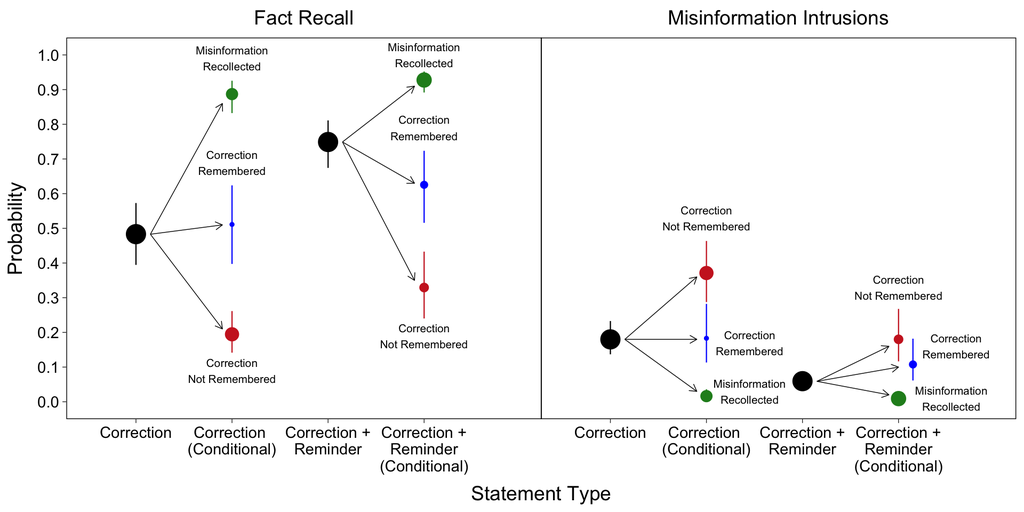

```r
#create data frames text labels
ann_text_class_1a <- data.frame(ItemType = 2, prob = c(.99, .69, .09), lab = c("Misinformation\nRecollected", "Correction\nRemembered", "Correction\nNot Remembered"), ResponseType = "Fact Recall")
ann_text_class_1b <- data.frame(ItemType = 4, prob = c(1.0, .79, .19), lab = c("Misinformation\nRecollected", "Correction\nRemembered", "Correction\nNot Remembered"), ResponseType = "Fact Recall")
ann_text_class_2a <- data.frame(ItemType = c(2.45, 2.45, 2), prob = c(.03, .17, .53), lab = c("Misinformation\nRecollected", "Correction\nRemembered", "Correction\nNot Remembered"), ResponseType = "Misinformation Intrusions")
ann_text_class_2b <- data.frame(ItemType = c(4.55, 4.60, 4), prob = c(.01, .16, .33), lab = c("Misinformation\nRecollected", "Correction\nRemembered", "Correction\nNot Remembered"), ResponseType = "Misinformation Intrusions")

#Create data frames for line segments
panel1a <- data.frame(x = 1.15, y = .483, xend = 1.9, yend = c(.21, .51, .86), ResponseType = "Fact Recall")
panel1b <- data.frame(x = 3.15, y = .749, xend = 3.9, yend = c(.35, .63, .91), ResponseType = "Fact Recall")
panel2a <- data.frame(x = 1.15, y = .180, xend = 1.9, yend = c(.03, .18, .36), ResponseType = "Misinformation Intrusions")
panel2b <- data.frame(x = 3.15, y = .059, xend = c(3.9, 4.0, 3.9), yend = c(.02, .10, .16), ResponseType = "Misinformation Intrusions")

#Plot List 1 correct recall for all responses and A-B, A-D conditionalized on change recollection
e1_recall_cond <- ggplot(recall_intrusion_bubble_df, aes(x = ItemType, y = prob, color = Correction_Class))+
                  geom_errorbar(aes(ymin = asymp.LCL, ymax = asymp.UCL, x = x_pos), position = position_dodge(), size = .4, width = 0, show.legend = FALSE) +
                  geom_point(aes(size = prop, x = x_pos))+
                  geom_segment(data = panel1a, aes(x=x,y=y,xend=xend,yend=yend),color="black",size = .25, arrow=arrow(length=unit(0.2,"cm")))+
                  geom_segment(data = panel1b, aes(x=x,y=y,xend=xend,yend=yend),color="black",size = .25, arrow=arrow(length=unit(0.2,"cm")))+
                  geom_segment(data = panel2a, aes(x=x,y=y,xend=xend,yend=yend),color="black",size = .25, arrow=arrow(length=unit(0.2,"cm")))+
                  geom_segment(data = panel2b, aes(x=x,y=y,xend=xend,yend=yend),color="black",size = .25, arrow=arrow(length=unit(0.2,"cm")))+
                  geom_text(data = ann_text_class_1a, aes(label = lab), color = "black", size = 2.75) +
                  geom_text(data = ann_text_class_1b, aes(label = lab), color = "black", size = 2.75) +
                  geom_text(data = ann_text_class_2a, aes(label = lab), color = "black", size = 2.75) +
                  geom_text(data = ann_text_class_2b, aes(label = lab), color = "black", size = 2.75) +
                  scale_color_manual("Response Classification", values=c("All" = "black", "Misinformation Recollected" = "forestgreen", "Correction Remembered" = "blue", "Correction Not Remembered" = "firebrick3")) +
                  guides(size = FALSE, color = FALSE) +
                  scale_x_continuous(breaks = seq(1, 4, 1), limits = c(.5, 5), labels = c("Correction", "Correction \n(Conditional)", "Correction +\nReminder", "Correction +\nReminder\n(Conditional)")) +
                  scale_y_continuous(name = "Probability",limits = c(0, 1), breaks = seq(0, 1, .1)) +
                  facet_grid(. ~ ResponseType) +
                  labs(x = "Statement Type") +
                  theme(legend.key=element_rect(fill="transparent",size=0),
                        legend.key.height=unit(1.2,"cm"),
                        legend.key.width=unit(.8,"cm"),
                        legend.text=element_text(size=10),
                        strip.background=element_blank(),
                        strip.text.x = element_text(size = 14, color = "black",margin = margin(0, 0, 8, 0)),
                        strip.text.y = element_text(size = 14, color = "black", margin = margin(0,0,0,8)),
                        axis.text.x=element_text(size=11,color="black"),
                        axis.text.y=element_text(size=11,color="black"),
                        axis.title.x=element_text(size=14, margin = margin(8, 0, 0, 0)),
                        axis.title.y=element_text(size=14, margin = margin(0, 8, 0, 0)),
                        axis.ticks.x = element_line(size=.25),
                        axis.ticks.y = element_line(size=.25),
                        plot.title = element_text(size = 16, hjust = 0.5),
                        panel.spacing.x = unit(-.01, "in"),
                        panel.background = element_blank(),
                        panel.grid.major = element_blank(),
                        panel.grid.major.x = element_blank(),
                        panel.grid.minor = element_blank(),
                        panel.border = element_rect(size=.5, fill = NA, color = "black"))
e1_recall_cond
```

Fit Mixed Effects Model to Beliefs in Correct Recall Data Conditionalized on Change Classifications

```r
#data frame including corrections and retractions
belief_correct_df <- cued_recall %>% filter(ItemType == "Correction" | ItemType == "Retraction")

#glmer for beliefs in correct recall
belief_correct_cond_lmer <- lmer(Belief.RESP ~ ItemType * Correction_Class + (1 | Subject) + (1 | Topic),
                                  data = subset(belief_correct_df, P2_Correct == 1))

#Run ANOVA
Anova(belief_correct_cond_lmer)
```

```
## Analysis of Deviance Table (Type II Wald chisquare tests)
##
## Response: Belief.RESP
##                             Chisq Df Pr(>Chisq)
## ItemType                   5.7855  1    0.01616 *
## Correction_Class          34.9681  2  2.551e-08 ***
## ItemType:Correction_Class  3.6828  2    0.15859
## ---
## Signif. codes:  0 '***' 0.001 '**' 0.01 '*' 0.05 '.' 0.1 ' ' 1
```

```r
#Pairwise comparisons
belief_correct_cond_emmeans <- emmeans(belief_correct_cond_lmer,
                                             list(pairwise ~ ItemType,
                                                  pairwise ~ Correction_Class,
                                                  pairwise ~ Correction_Class | ItemType), type = "response")
```

```
## NOTE: Results may be misleading due to involvement in interactions
## NOTE: Results may be misleading due to involvement in interactions
```

```r
belief_correct_cond_emmeans
```

```
## $`emmeans of ItemType`
##  ItemType   emmean     SE  df lower.CL upper.CL
##  Correction   4.47 0.0966 182     4.28     4.66
##  Retraction   4.67 0.0963 184     4.48     4.86
##
## Results are averaged over the levels of: Correction_Class
## Degrees-of-freedom method: kenward-roger
## Confidence level used: 0.95
##
## $`pairwise differences of ItemType`
##  1                       estimate     SE   df t.ratio p.value
##  Correction - Retraction   -0.192 0.0738 1621 -2.599  0.0094
##
## Results are averaged over the levels of: Correction_Class
## Degrees-of-freedom method: kenward-roger
##
## $`emmeans of Correction_Class`
##  Correction_Class           emmean     SE  df lower.CL upper.CL
##  Correction Not Remembered    4.33 0.1142 336     4.11     4.56
##  Correction Remembered        4.56 0.1103 292     4.35     4.78
##  Misinformation Recollected   4.82 0.0903 136     4.64     4.99
##
## Results are averaged over the levels of: ItemType
## Degrees-of-freedom method: kenward-roger
## Confidence level used: 0.95
##
## $`pairwise differences of Correction_Class`
##  1                                                      estimate     SE   df
##  Correction Not Remembered - Correction Remembered        -0.229 0.1123 1678
##  Correction Not Remembered - Misinformation Recollected   -0.482 0.0931 1688
##  Correction Remembered - Misinformation Recollected       -0.253 0.0861 1642
##  t.ratio p.value
##  -2.042  0.1026
##  -5.177  <.0001
##  -2.936  0.0095
##
## Results are averaged over the levels of: ItemType
## Degrees-of-freedom method: kenward-roger
## P value adjustment: tukey method for comparing a family of 3 estimates
##
```

[output cut: 24 more lines]

```
##  -5.501  <.0001
##  -1.813  0.1657
##
## ItemType = Retraction:
##  2                                                      estimate    SE   df
##  Correction Not Remembered - Correction Remembered       -0.0489 0.160 1668
##  Correction Not Remembered - Misinformation Recollected  -0.3253 0.138 1676
##  Correction Remembered - Misinformation Recollected      -0.2764 0.105 1672
##  t.ratio p.value
##  -0.306  0.9496
##  -2.363  0.0479
##  -2.627  0.0236
##
## Degrees-of-freedom method: kenward-roger
## P value adjustment: tukey method for comparing a family of 3 estimates
```

```r
#extract estimated probabilities
belief_correct_cond_emmeans_df <- as_tibble(belief_correct_cond_emmeans$`emmeans of Correction_Class | ItemType`)
belief_correct_cond_emmeans_df
```

```
## # A tibble: 6 x 7
##   Correction_Class           ItemType   emmean     SE    df lower.CL upper.CL
##   <fct>                      <fct>       <dbl>  <dbl> <dbl>    <dbl>    <dbl>
## 1 Correction Not Remembered  Correction   4.13 0.126   476.     3.88     4.37
## 2 Correction Remembered      Correction   4.53 0.138   620.     4.26     4.81
## 3 Misinformation Recollected Correction   4.76 0.101   204.     4.57     4.96
## 4 Correction Not Remembered  Retraction   4.54 0.150   779.     4.25     4.84
## 5 Correction Remembered      Retraction   4.59 0.123   429.     4.35     4.83
## 6 Misinformation Recollected Retraction   4.87 0.0930  155.     4.68     5.05
```

Create Data Frame for Bubble Plots of Conditional Analyses of Beliefs in Correct Recall

```r
#compute overall counts and proportions for each item type
plot_df <- cued_recall %>%
           group_by(ItemType) %>%
           filter(ItemType == "Correction" | ItemType == "Retraction", P2_Correct == 1) %>%
           summarise(n = length(P2_Correct)) %>%
           mutate(prop = n/1440)
           plot_df$Correction_Class = "All"
plot_df
```

```
## # A tibble: 2 x 4
##   ItemType       n  prop Correction_Class
##   <chr>      <int> <dbl> <chr>
## 1 Correction   710 0.493 All
## 2 Retraction   992 0.689 All
```

```r
#compute model estimates probabilities of overall belief ratings for correct recalls
plot_df_boot <- belief_correct_lmer_emmeans_df %>%
                filter(ItemType == "Correction" | ItemType == "Retraction") %>%
                dplyr::select(-SE, -df, -ci_point)
plot_df_boot
```

```
## # A tibble: 2 x 5
##   ItemType   emmean asymp.LCL asymp.UCL ResponseType
##   <fct>       <dbl>     <dbl>     <dbl> <chr>
## 1 Correction   4.55      4.36      4.74 Correct Facts
## 2 Retraction   4.76      4.58      4.95 Correct Facts
```

```r
#merge data frames for conditional beliefs in correct recall
plot_df_uncond <- merge(plot_df, plot_df_boot)

plot_df_uncond
```

```
##     ItemType   n      prop Correction_Class   emmean asymp.LCL asymp.UCL
## 1 Correction 710 0.4930556              All 4.550584  4.359875  4.741293
## 2 Retraction 992 0.6888889              All 4.761507  4.577852  4.945162
##    ResponseType
## 1 Correct Facts
## 2 Correct Facts
```

```r
#Compute counts and proportions for belief in correct recalls conditionalized change classifications at test
plot_df_cond <- cued_recall %>%
                filter(ItemType == "Correction" | ItemType == "Retraction", P2_Correct == 1) %>%
                group_by(ItemType, Correction_Class) %>%
                summarise(n = length(Belief.RESP)) %>%
                mutate(prop = n / 1440) %>%
                as_tibble()
plot_df_cond
```

```
## # A tibble: 6 x 4
##   ItemType   Correction_Class               n   prop
##   <chr>      <chr>                      <int>  <dbl>
## 1 Correction Correction Not Remembered    150 0.104
## 2 Correction Correction Remembered        115 0.0799
## 3 Correction Misinformation Recollected   445 0.309
## 4 Retraction Correction Not Remembered     89 0.0618
## 5 Retraction Correction Remembered        173 0.120
## 6 Retraction Misinformation Recollected   730 0.507
```

```r
plot_df_cond_boot <- belief_correct_cond_emmeans_df %>%
                     dplyr::select(-SE, -df)
plot_df_cond_boot
```

```
## # A tibble: 6 x 5
##   Correction_Class           ItemType   emmean lower.CL upper.CL
##   <fct>                      <fct>       <dbl>    <dbl>    <dbl>
## 1 Correction Not Remembered  Correction   4.13     3.88     4.37
## 2 Correction Remembered      Correction   4.53     4.26     4.81
## 3 Misinformation Recollected Correction   4.76     4.57     4.96
## 4 Correction Not Remembered  Retraction   4.54     4.25     4.84
## 5 Correction Remembered      Retraction   4.59     4.35     4.83
## 6 Misinformation Recollected Retraction   4.87     4.68     5.05
```

```r
#merge data frames for conditional correct recall
plot_df_cond <- merge(plot_df_cond, plot_df_cond_boot)

plot_df_cond
```

```
##     ItemType           Correction_Class   n       prop   emmean lower.CL
## 1 Correction  Correction Not Remembered 150 0.10416667 4.125018 3.876735
## 2 Correction      Correction Remembered 115 0.07986111 4.534587 4.263613
## 3 Correction Misinformation Recollected 445 0.30902778 4.763733 4.565534
## 4 Retraction  Correction Not Remembered  89 0.06180556 4.541491 4.246419
## 5 Retraction      Correction Remembered 173 0.12013889 4.590367 4.348783
## 6 Retraction Misinformation Recollected 730 0.50694444 4.866812 4.683193
##   upper.CL
## 1 4.373300
## 2 4.805560
## 3 4.961932
## 4 4.836562
## 5 4.831951
## 6 5.050432
```

```r
#change conditional labels for item types in conditional recall
plot_df_cond$ItemType <- ifelse(plot_df_cond$ItemType == "Correction", "Correction (Conditional)", "Retraction (Conditional)")

colnames(plot_df_cond)[6] <- "asymp.LCL"
colnames(plot_df_cond)[7] <- "asymp.UCL"

plot_df_cond
```

```
##                   ItemType           Correction_Class   n       prop   emmean
## 1 Correction (Conditional)  Correction Not Remembered 150 0.10416667 4.125018
## 2 Correction (Conditional)      Correction Remembered 115 0.07986111 4.534587
## 3 Correction (Conditional) Misinformation Recollected 445 0.30902778 4.763733
## 4 Retraction (Conditional)  Correction Not Remembered  89 0.06180556 4.541491
## 5 Retraction (Conditional)      Correction Remembered 173 0.12013889 4.590367
## 6 Retraction (Conditional) Misinformation Recollected 730 0.50694444 4.866812
##   asymp.LCL asymp.UCL
## 1  3.876735  4.373300
## 2  4.263613  4.805560
## 3  4.565534  4.961932
## 4  4.246419  4.836562
## 5  4.348783  4.831951
## 6  4.683193  5.050432
```

```r
#Bind data frames
belief_correct_bubble_df <- bind_rows(plot_df_uncond, plot_df_cond)

belief_correct_bubble_df
```

```
##                   ItemType   n       prop           Correction_Class   emmean
## 1               Correction 710 0.49305556                        All 4.550584
## 2               Retraction 992 0.68888889                        All 4.761507
## 3 Correction (Conditional) 150 0.10416667  Correction Not Remembered 4.125018
## 4 Correction (Conditional) 115 0.07986111      Correction Remembered 4.534587
## 5 Correction (Conditional) 445 0.30902778 Misinformation Recollected 4.763733
## 6 Retraction (Conditional)  89 0.06180556  Correction Not Remembered 4.541491
## 7 Retraction (Conditional) 173 0.12013889      Correction Remembered 4.590367
## 8 Retraction (Conditional) 730 0.50694444 Misinformation Recollected 4.866812
##   asymp.LCL asymp.UCL  ResponseType
## 1  4.359875  4.741293 Correct Facts
## 2  4.577852  4.945162 Correct Facts
## 3  3.876735  4.373300          <NA>
## 4  4.263613  4.805560          <NA>
## 5  4.565534  4.961932          <NA>
## 6  4.246419  4.836562          <NA>
## 7  4.348783  4.831951          <NA>
## 8  4.683193  5.050432          <NA>
```

```r
#reorder factor levels
belief_correct_bubble_df$ItemType <- factor(belief_correct_bubble_df$ItemType,
                                            levels = c("Correction", "Correction (Conditional)",
                                                       "Retraction", "Retraction (Conditional)"))

#create variable for x position of points
belief_correct_bubble_df$x_pos <- c(1, 3, 2, 2.15, 2, 4.25, 4.15, 4)

#add variable for response type
belief_correct_bubble_df$ResponseType <- "Fact Recall"

belief_correct_bubble_df
```

```
##                   ItemType   n       prop           Correction_Class   emmean
## 1               Correction 710 0.49305556                        All 4.550584
## 2               Retraction 992 0.68888889                        All 4.761507
## 3 Correction (Conditional) 150 0.10416667  Correction Not Remembered 4.125018
## 4 Correction (Conditional) 115 0.07986111      Correction Remembered 4.534587
## 5 Correction (Conditional) 445 0.30902778 Misinformation Recollected 4.763733
## 6 Retraction (Conditional)  89 0.06180556  Correction Not Remembered 4.541491
## 7 Retraction (Conditional) 173 0.12013889      Correction Remembered 4.590367
## 8 Retraction (Conditional) 730 0.50694444 Misinformation Recollected 4.866812
##   asymp.LCL asymp.UCL ResponseType x_pos
## 1  4.359875  4.741293  Fact Recall  1.00
## 2  4.577852  4.945162  Fact Recall  3.00
## 3  3.876735  4.373300  Fact Recall  2.00
## 4  4.263613  4.805560  Fact Recall  2.15
## 5  4.565534  4.961932  Fact Recall  2.00
## 6  4.246419  4.836562  Fact Recall  4.25
## 7  4.348783  4.831951  Fact Recall  4.15
## 8  4.683193  5.050432  Fact Recall  4.00
```

Fit Mixed Effects Model to Beliefs in Intratrial Intrusions Data Conditionalized on Change Classifications

```r
#data frame including corrections and retractions
belief_intrusion_df <- cued_recall %>% filter(ItemType == "Correction" | ItemType == "Retraction")

#glmer for beliefs in correct recall
belief_intrusion_cond_glmer <- lmer(Belief.RESP ~ ItemType * Correction_Class + (1 | Subject) + (1 | Topic),
                                    data = subset(belief_intrusion_df, P1_Intrusion == 1))

#Run ANOVA
Anova(belief_intrusion_cond_glmer)
```

```
## Analysis of Deviance Table (Type II Wald chisquare tests)
##
## Response: Belief.RESP
##                             Chisq Df Pr(>Chisq)
## ItemType                   9.5052  1   0.002049 **
## Correction_Class          11.0699  2   0.003946 **
## ItemType:Correction_Class  3.9570  2   0.138276
## ---
## Signif. codes:  0 '***' 0.001 '**' 0.01 '*' 0.05 '.' 0.1 ' ' 1
```

```r
#Pairwise comparisons
belief_intrusion_cond_emmeans <- emmeans(belief_intrusion_cond_glmer,
                                             list(pairwise ~ ItemType,
                                                  pairwise ~ Correction_Class,
                                                  pairwise ~ Correction_Class | ItemType), type = "response")
```

```
## NOTE: Results may be misleading due to involvement in interactions
## NOTE: Results may be misleading due to involvement in interactions
```

```r
belief_intrusion_cond_emmeans
```

```
## $`emmeans of ItemType`
##  ItemType   emmean    SE  df lower.CL upper.CL
##  Correction   3.92 0.179 249     3.57     4.27
##  Retraction   3.18 0.189 292     2.81     3.56
##
## Results are averaged over the levels of: Correction_Class
## Degrees-of-freedom method: kenward-roger
## Confidence level used: 0.95
##
## $`pairwise differences of ItemType`
##  1                       estimate    SE  df t.ratio p.value
##  Correction - Retraction    0.735 0.222 426 3.309   0.0010
##
## Results are averaged over the levels of: Correction_Class
## Degrees-of-freedom method: kenward-roger
##
## $`emmeans of Correction_Class`
##  Correction_Class           emmean    SE  df lower.CL upper.CL
##  Correction Not Remembered    3.97 0.134 110     3.71     4.24
##  Correction Remembered        3.32 0.191 270     2.95     3.70
##  Misinformation Recollected   3.36 0.303 428     2.76     3.95
##
## Results are averaged over the levels of: ItemType
## Degrees-of-freedom method: kenward-roger
## Confidence level used: 0.95
##
## $`pairwise differences of Correction_Class`
##  1                                                      estimate    SE  df
##  Correction Not Remembered - Correction Remembered        0.6504 0.195 449
##  Correction Not Remembered - Misinformation Recollected   0.6149 0.309 446
##  Correction Remembered - Misinformation Recollected      -0.0355 0.334 443
##  t.ratio p.value
##   3.331  0.0027
##   1.992  0.1153
##  -0.106  0.9938
##
## Results are averaged over the levels of: ItemType
## Degrees-of-freedom method: kenward-roger
## P value adjustment: tukey method for comparing a family of 3 estimates
##
```

[output cut: 24 more lines]

```
##   0.417  0.9087
##  -0.432  0.9022
##
## ItemType = Retraction:
##  2                                                      estimate    SE  df
##  Correction Not Remembered - Correction Remembered         0.930 0.291 434
##  Correction Not Remembered - Misinformation Recollected    1.057 0.445 438
##  Correction Remembered - Misinformation Recollected        0.126 0.472 434
##  t.ratio p.value
##   3.193  0.0043
##   2.373  0.0474
##   0.267  0.9614
##
## Degrees-of-freedom method: kenward-roger
## P value adjustment: tukey method for comparing a family of 3 estimates
```

```r
#extract estimated probabilities
belief_intrusion_cond_emmeans <- as_tibble(belief_intrusion_cond_emmeans$`emmeans of Correction_Class | ItemType`)
belief_intrusion_cond_emmeans
```

```
## # A tibble: 6 x 7
##   Correction_Class           ItemType   emmean    SE    df lower.CL upper.CL
##   <fct>                      <fct>       <dbl> <dbl> <dbl>    <dbl>    <dbl>
## 1 Correction Not Remembered  Correction   4.10 0.133  113.     3.84     4.36
## 2 Correction Remembered      Correction   3.73 0.231  364.     3.28     4.18
## 3 Misinformation Recollected Correction   3.93 0.413  448.     3.12     4.74
## 4 Correction Not Remembered  Retraction   3.85 0.191  288.     3.47     4.22
## 5 Correction Remembered      Retraction   2.92 0.255  404.     2.41     3.42
## 6 Misinformation Recollected Retraction   2.79 0.418  443.     1.97     3.61
```

Fit Mixed Effects Model to Misinformation Intrusionss excluding Misinformation Recollection

```r
#data frame including corrections and retractions
belief_intrusion_no_mis_rec_df <- cued_recall %>%
                                  filter(ItemType == "Correction" | ItemType == "Retraction") %>%
                                  filter(Correction_Class != "Misinformation Recollected")

#glmer for beliefs in correct recall
belief_intrusion_no_mis_cond_glmer <- lmer(Belief.RESP ~ ItemType * Correction_Class + (1 | Subject) + (1 | Topic),
                                      data = subset(belief_intrusion_no_mis_rec_df, P1_Intrusion == 1))

#Run ANOVA
Anova(belief_intrusion_no_mis_cond_glmer)
```

```
## Analysis of Deviance Table (Type II Wald chisquare tests)
##
## Response: Belief.RESP
##                            Chisq Df Pr(>Chisq)
## ItemType                  7.1787  1   0.007377 **
## Correction_Class          9.4872  1   0.002069 **
## ItemType:Correction_Class 2.8538  1   0.091158 .
## ---
## Signif. codes:  0 '***' 0.001 '**' 0.01 '*' 0.05 '.' 0.1 ' ' 1
```

```r
#Pairwise comparisons
belief_intrusion_no_mis_cond_emmeans <- emmeans(belief_intrusion_no_mis_cond_glmer,
                                                list(pairwise ~ ItemType,
                                                     pairwise ~ Correction_Class,
                                                     pairwise ~ Correction_Class | ItemType), type = "response")
```

```
## NOTE: Results may be misleading due to involvement in interactions
## NOTE: Results may be misleading due to involvement in interactions
```

```r
belief_intrusion_no_mis_cond_emmeans
```

```
## $`emmeans of ItemType`
##  ItemType   emmean    SE  df lower.CL upper.CL
##  Correction   3.91 0.146 144     3.62     4.20
##  Retraction   3.36 0.171 213     3.02     3.69
##
## Results are averaged over the levels of: Correction_Class
## Degrees-of-freedom method: kenward-roger
## Confidence level used: 0.95
##
## $`pairwise differences of ItemType`
##  1                       estimate    SE  df t.ratio p.value
##  Correction - Retraction    0.555 0.178 391 3.127   0.0019
##
## Results are averaged over the levels of: Correction_Class
## Degrees-of-freedom method: kenward-roger
##
## $`emmeans of Correction_Class`
##  Correction_Class          emmean    SE  df lower.CL upper.CL
##  Correction Not Remembered   3.96 0.133 100     3.70     4.22
##  Correction Remembered       3.31 0.191 250     2.93     3.68
##
## Results are averaged over the levels of: ItemType
## Degrees-of-freedom method: kenward-roger
## Confidence level used: 0.95
##
## $`pairwise differences of Correction_Class`
##  1                                                 estimate    SE  df t.ratio
##  Correction Not Remembered - Correction Remembered    0.654 0.196 423 3.330
##  p.value
##  0.0009
##
## Results are averaged over the levels of: ItemType
## Degrees-of-freedom method: kenward-roger
##
## $`emmeans of Correction_Class | ItemType`
## ItemType = Correction:
##  Correction_Class          emmean    SE  df lower.CL upper.CL
##  Correction Not Remembered   4.09 0.132 102     3.82     4.35
##  Correction Remembered       3.74 0.231 339     3.28     4.19
##
## ItemType = Retraction:
##  Correction_Class          emmean    SE  df lower.CL upper.CL
##  Correction Not Remembered   3.83 0.190 267     3.46     4.21
##  Correction Remembered       2.88 0.256 377     2.37     3.38
##
## Degrees-of-freedom method: kenward-roger
## Confidence level used: 0.95
##
## $`pairwise differences of Correction_Class | ItemType`
## ItemType = Correction:
##  2                                                 estimate    SE  df t.ratio
##  Correction Not Remembered - Correction Remembered    0.350 0.239 422 1.465
##  p.value
##  0.1437
##
## ItemType = Retraction:
##  2                                                 estimate    SE  df t.ratio
##  Correction Not Remembered - Correction Remembered    0.959 0.293 411 3.268
##  p.value
##  0.0012
##
## Degrees-of-freedom method: kenward-roger
```

```r
#extract estimated probabilities
belief_intrusion_no_mis_cond_emmeans <- as_tibble(belief_intrusion_no_mis_cond_emmeans$`emmeans of Correction_Class | ItemType`)
belief_intrusion_no_mis_cond_emmeans
```

```
## # A tibble: 4 x 7
##   Correction_Class          ItemType   emmean    SE    df lower.CL upper.CL
##   <fct>                     <fct>       <dbl> <dbl> <dbl>    <dbl>    <dbl>
## 1 Correction Not Remembered Correction   4.09 0.132  102.     3.82     4.35
## 2 Correction Remembered     Correction   3.74 0.231  339.     3.28     4.19
## 3 Correction Not Remembered Retraction   3.83 0.190  267.     3.46     4.21
## 4 Correction Remembered     Retraction   2.88 0.256  377.     2.37     3.38
```

Create Data Frame for Bubble Plots of Conditional Analyses of Beliefs in Intratrial Intrusions

```r
#compute overall counts and proportions for each item type
plot_df <- cued_recall %>%
           group_by(ItemType) %>%
           filter(ItemType == "Correction" | ItemType == "Retraction", P1_Intrusion == 1) %>%
           summarise(n = length(P1_Intrusion)) %>%
           mutate(prop = n/1440)
           plot_df$Correction_Class = "All"
plot_df
```

```
## # A tibble: 2 x 4
##   ItemType       n  prop Correction_Class
##   <chr>      <int> <dbl> <chr>
## 1 Correction   312 0.217 All
## 2 Retraction   145 0.101 All
```

```r
#compute model estimates probabilities of overall belief ratings for correct recalls
plot_df_boot <- belief_misinfo_lmer_emmeans_df %>%
                filter(ItemType == "Correction" | ItemType == "Retraction") %>%
                dplyr::select(-SE, -df, -ci_point)
plot_df_boot
```

```
## # A tibble: 2 x 4
##   ItemType   emmean lower.CL upper.CL
##   <fct>       <dbl>    <dbl>    <dbl>
## 1 Correction   3.95     3.62     4.27
## 2 Retraction   3.39     2.95     3.84
```

```r
#merge data frames for conditional beliefs in correct recall
plot_df_uncond <- merge(plot_df, plot_df_boot)

plot_df_uncond
```

```
##     ItemType   n      prop Correction_Class   emmean lower.CL upper.CL
## 1 Correction 312 0.2166667              All 3.946426 3.622107 4.270744
## 2 Retraction 145 0.1006944              All 3.394925 2.953070 3.836779
```

```r
#Compute counts and proportions for belief in correct recalls conditionalized change classifications at test
plot_df_cond <- cued_recall %>%
                filter(ItemType == "Correction" | ItemType == "Retraction", P1_Intrusion == 1) %>%
                group_by(ItemType, Correction_Class) %>%
                summarise(n = length(Belief.RESP)) %>%
                mutate(prop = n / 1440) %>%
                as_tibble()
plot_df_cond
```

```
## # A tibble: 6 x 4
##   ItemType   Correction_Class               n    prop
##   <chr>      <chr>                      <int>   <dbl>
## 1 Correction Correction Not Remembered    242 0.168
## 2 Correction Correction Remembered         55 0.0382
## 3 Correction Misinformation Recollected    15 0.0104
## 4 Retraction Correction Not Remembered     86 0.0597
## 5 Retraction Correction Remembered         45 0.0312
## 6 Retraction Misinformation Recollected    14 0.00972
```

```r
plot_df_cond_boot <- belief_intrusion_cond_emmeans %>%
                     dplyr::select(-SE, -df)
plot_df_cond_boot
```

```
## # A tibble: 6 x 5
##   Correction_Class           ItemType   emmean lower.CL upper.CL
##   <fct>                      <fct>       <dbl>    <dbl>    <dbl>
## 1 Correction Not Remembered  Correction   4.10     3.84     4.36
## 2 Correction Remembered      Correction   3.73     3.28     4.18
## 3 Misinformation Recollected Correction   3.93     3.12     4.74
## 4 Correction Not Remembered  Retraction   3.85     3.47     4.22
## 5 Correction Remembered      Retraction   2.92     2.41     3.42
## 6 Misinformation Recollected Retraction   2.79     1.97     3.61
```

```r
#merge data frames for conditional correct recall
plot_df_cond <- merge(plot_df_cond, plot_df_cond_boot)

plot_df_cond
```

```
##     ItemType           Correction_Class   n        prop   emmean lower.CL
## 1 Correction  Correction Not Remembered 242 0.168055556 4.100699 3.836675
## 2 Correction      Correction Remembered  55 0.038194444 3.730330 3.275769
## 3 Correction Misinformation Recollected  15 0.010416667 3.927560 3.115950
## 4 Retraction  Correction Not Remembered  86 0.059722222 3.846689 3.471596
## 5 Retraction      Correction Remembered  45 0.031250000 2.916204 2.414830
## 6 Retraction Misinformation Recollected  14 0.009722222 2.789984 1.969029
##   upper.CL
## 1 4.364723
## 2 4.184890
## 3 4.739171
## 4 4.221781
## 5 3.417578
## 6 3.610939
```

```r
#change conditional labels for item types in conditional recall
plot_df_cond$ItemType <- ifelse(plot_df_cond$ItemType == "Correction", "Correction (Conditional)", "Retraction (Conditional)")

#Bind data frames
belief_intrusion_bubble_df <- bind_rows(plot_df_uncond, plot_df_cond)

belief_intrusion_bubble_df
```

```
##                   ItemType   n        prop           Correction_Class   emmean
## 1               Correction 312 0.216666667                        All 3.946426
## 2               Retraction 145 0.100694444                        All 3.394925
## 3 Correction (Conditional) 242 0.168055556  Correction Not Remembered 4.100699
## 4 Correction (Conditional)  55 0.038194444      Correction Remembered 3.730330
## 5 Correction (Conditional)  15 0.010416667 Misinformation Recollected 3.927560
## 6 Retraction (Conditional)  86 0.059722222  Correction Not Remembered 3.846689
## 7 Retraction (Conditional)  45 0.031250000      Correction Remembered 2.916204
## 8 Retraction (Conditional)  14 0.009722222 Misinformation Recollected 2.789984
##   lower.CL upper.CL
## 1 3.622107 4.270744
## 2 2.953070 3.836779
## 3 3.836675 4.364723
## 4 3.275769 4.184890
## 5 3.115950 4.739171
## 6 3.471596 4.221781
## 7 2.414830 3.417578
## 8 1.969029 3.610939
```

```r
#change confidence interval column names
colnames(belief_intrusion_bubble_df)[6] <- "asymp.LCL"
colnames(belief_intrusion_bubble_df)[7] <- "asymp.UCL"

belief_intrusion_bubble_df
```

```
##                   ItemType   n        prop           Correction_Class   emmean
## 1               Correction 312 0.216666667                        All 3.946426
## 2               Retraction 145 0.100694444                        All 3.394925
## 3 Correction (Conditional) 242 0.168055556  Correction Not Remembered 4.100699
## 4 Correction (Conditional)  55 0.038194444      Correction Remembered 3.730330
## 5 Correction (Conditional)  15 0.010416667 Misinformation Recollected 3.927560
## 6 Retraction (Conditional)  86 0.059722222  Correction Not Remembered 3.846689
## 7 Retraction (Conditional)  45 0.031250000      Correction Remembered 2.916204
## 8 Retraction (Conditional)  14 0.009722222 Misinformation Recollected 2.789984
##   asymp.LCL asymp.UCL
## 1  3.622107  4.270744
## 2  2.953070  3.836779
## 3  3.836675  4.364723
## 4  3.275769  4.184890
## 5  3.115950  4.739171
## 6  3.471596  4.221781
## 7  2.414830  3.417578
## 8  1.969029  3.610939
```

```r
#reorder factor levels
belief_intrusion_bubble_df$ItemType <- factor(belief_intrusion_bubble_df$ItemType,
                                              levels = c("Correction", "Correction (Conditional)",
                                                         "Retraction", "Retraction (Conditional)"))

#create variable for x position of points
belief_intrusion_bubble_df$x_pos <- c(1, 3, 2.25, 2.15, 2, 4.25, 4.15, 4)

#add variable for response type

belief_intrusion_bubble_df$ResponseType <- "Misinformation Intrusions"

belief_intrusion_bubble_df
```

```
##                   ItemType   n        prop           Correction_Class   emmean
## 1               Correction 312 0.216666667                        All 3.946426
## 2               Retraction 145 0.100694444                        All 3.394925
## 3 Correction (Conditional) 242 0.168055556  Correction Not Remembered 4.100699
## 4 Correction (Conditional)  55 0.038194444      Correction Remembered 3.730330
## 5 Correction (Conditional)  15 0.010416667 Misinformation Recollected 3.927560
## 6 Retraction (Conditional)  86 0.059722222  Correction Not Remembered 3.846689
## 7 Retraction (Conditional)  45 0.031250000      Correction Remembered 2.916204
## 8 Retraction (Conditional)  14 0.009722222 Misinformation Recollected 2.789984
##   asymp.LCL asymp.UCL x_pos              ResponseType
## 1  3.622107  4.270744  1.00 Misinformation Intrusions
## 2  2.953070  3.836779  3.00 Misinformation Intrusions
## 3  3.836675  4.364723  2.25 Misinformation Intrusions
## 4  3.275769  4.184890  2.15 Misinformation Intrusions
## 5  3.115950  4.739171  2.00 Misinformation Intrusions
## 6  3.471596  4.221781  4.25 Misinformation Intrusions
## 7  2.414830  3.417578  4.15 Misinformation Intrusions
## 8  1.969029  3.610939  4.00 Misinformation Intrusions
```

Combine Conditional Belief Rating Data Frames

```r
belief_cond_df <- bind_rows(belief_correct_bubble_df, belief_intrusion_bubble_df)

colnames(belief_cond_df)[5] <- "prob"


belief_cond_df
```

```
##                    ItemType   n        prop           Correction_Class     prob
## 1                Correction 710 0.493055556                        All 4.550584
## 2                Retraction 992 0.688888889                        All 4.761507
## 3  Correction (Conditional) 150 0.104166667  Correction Not Remembered 4.125018
## 4  Correction (Conditional) 115 0.079861111      Correction Remembered 4.534587
## 5  Correction (Conditional) 445 0.309027778 Misinformation Recollected 4.763733
## 6  Retraction (Conditional)  89 0.061805556  Correction Not Remembered 4.541491
## 7  Retraction (Conditional) 173 0.120138889      Correction Remembered 4.590367
## 8  Retraction (Conditional) 730 0.506944444 Misinformation Recollected 4.866812
## 9                Correction 312 0.216666667                        All 3.946426
## 10               Retraction 145 0.100694444                        All 3.394925
## 11 Correction (Conditional) 242 0.168055556  Correction Not Remembered 4.100699
## 12 Correction (Conditional)  55 0.038194444      Correction Remembered 3.730330
## 13 Correction (Conditional)  15 0.010416667 Misinformation Recollected 3.927560
## 14 Retraction (Conditional)  86 0.059722222  Correction Not Remembered 3.846689
```

[output cut: 19 more lines]

Visualize Belief Ratings Conditionalized on Correction Classifications

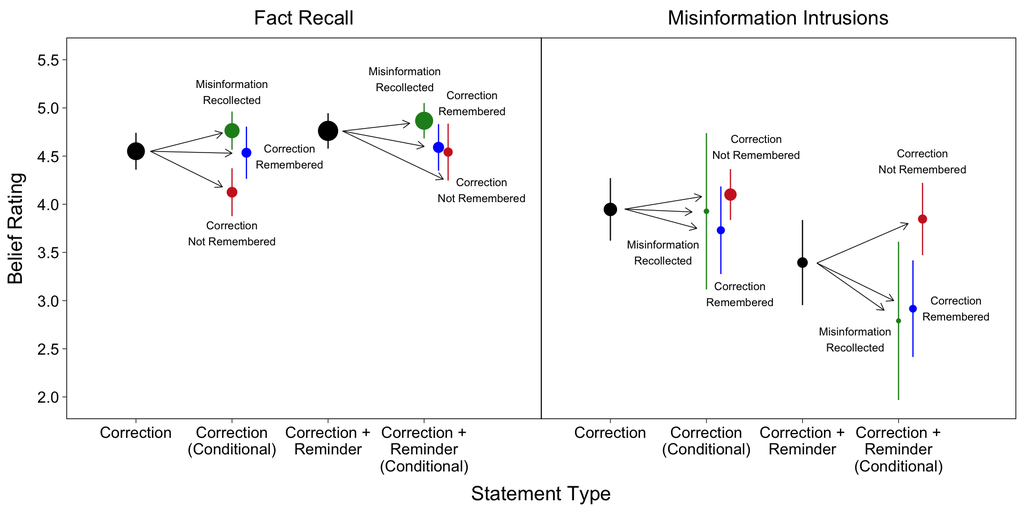

```r
#create data frames text labels
ann_text_class_1a <- data.frame(ItemType = c(2.00, 2.60, 2.00), prob = c(5.17, 4.50, 3.70), lab = c("Misinformation\nRecollected", "Correction\nRemembered", "Correction\nNot Remembered"), ResponseType = "Fact Recall")
ann_text_class_1b <- data.frame(ItemType = c(3.80, 4.50, 4.60), prob = c(5.30, 5.05, 4.15), lab = c("Misinformation\nRecollected", "Correction\nRemembered", "Correction\nNot Remembered"), ResponseType = "Fact Recall")
ann_text_class_2a <- data.frame(ItemType = c(1.55, 2.35, 2.52), prob = c(3.50, 3.07, 4.60), lab = c("Misinformation\nRecollected", "Correction\nRemembered", "Correction\nNot Remembered"), ResponseType = "Misinformation Intrusions")
ann_text_class_2b <- data.frame(ItemType = c(3.55, 4.60, 4.25), prob = c(2.60, 2.92, 4.45), lab = c("Misinformation\nRecollected", "Correction\nRemembered", "Correction\nNot Remembered"), ResponseType = "Misinformation Intrusions")

#Create data frames for line segments
panel1a <- data.frame(x = 1.15, y = 4.55, xend = c(1.9, 2.0, 1.9), yend = c(4.18, 4.53, 4.74), ResponseType = "Fact Recall")
panel1b <- data.frame(x = 3.15, y = 4.76, xend = c(4.2, 4.0, 3.85), yend = c(4.26, 4.60, 4.84), ResponseType = "Fact Recall")
panel2a <- data.frame(x = 1.15, y = 3.95, xend = c(1.95, 1.85, 1.90), yend = c(4.08, 3.92, 3.75), ResponseType = "Misinformation Intrusions")
panel2b <- data.frame(x = 3.15, y = 3.39, xend = c(4.1, 3.95, 3.85), yend = c(3.80, 3.00, 2.90), ResponseType = "Misinformation Intrusions")

#bubble plot
e1_belief_cond <- ggplot(belief_cond_df, aes(x = ItemType, y = prob, color = Correction_Class)) +
                  geom_errorbar(aes(ymin = asymp.LCL, ymax = asymp.UCL, x = x_pos), position = position_dodge(), size = .4, width = 0, show.legend = FALSE) +
                  geom_point(aes(size = prop, x = x_pos)) +
                  geom_segment(data = panel1a, aes(x=x,y=y,xend=xend,yend=yend),color="black",size = .25, arrow=arrow(length=unit(0.2,"cm")))+
                  geom_segment(data = panel1b, aes(x=x,y=y,xend=xend,yend=yend),color="black",size = .25, arrow=arrow(length=unit(0.2,"cm")))+
                  geom_segment(data = panel2a, aes(x=x,y=y,xend=xend,yend=yend),color="black",size = .25, arrow=arrow(length=unit(0.2,"cm")))+
                  geom_segment(data = panel2b, aes(x=x,y=y,xend=xend,yend=yend),color="black",size = .25, arrow=arrow(length=unit(0.2,"cm")))+
                  geom_text(data = ann_text_class_1a, aes(label = lab), color = "black", size = 2.75) +
                  geom_text(data = ann_text_class_1b, aes(label = lab), color = "black", size = 2.75) +
                  geom_text(data = ann_text_class_2a, aes(label = lab), color = "black", size = 2.75) +
                  geom_text(data = ann_text_class_2b, aes(label = lab), color = "black", size = 2.75) +
                  scale_color_manual("Response Classification", values=c("All" = "black", "Misinformation Recollected" = "forestgreen", "Correction Remembered" = "blue", "Correction Not Remembered" = "firebrick3")) +
                  guides(size=FALSE, color=FALSE) +
                  facet_grid(. ~ ResponseType) +
                  scale_x_continuous(breaks=seq(1, 4, 1), limits = c(.5, 5), labels=c("Correction", "Correction\n(Conditional)", "Correction +\nReminder", "Correction +\nReminder\n(Conditional)")) +
                  scale_y_continuous(name="Belief Rating",limits=c(1.95, 5.55), breaks=seq(2, 5.5, .5))+
                  labs(x = "Statement Type") +
                  theme(legend.key=element_rect(fill="transparent",size=0),
                        legend.key.height=unit(1.2,"cm"),
                        legend.key.width=unit(.8,"cm"),
                        legend.text=element_text(size=10),
                        strip.background=element_blank(),
                        strip.text.x = element_text(size = 14, color = "black",margin = margin(0, 0, 8, 0)),
                        strip.text.y = element_text(size = 14, color = "black", margin = margin(0,0,0,8)),
                        axis.text.x=element_text(size=11,color="black"),
                        axis.text.y=element_text(size=11,color="black"),
                        axis.title.x=element_text(size=14, margin = margin(8, 0, 0, 0)),
                        axis.title.y=element_text(size=14, margin = margin(0, 8, 0, 0)),
                        axis.ticks.x = element_line(size=.25),
                        axis.ticks.y = element_line(size=.25),
                        plot.title = element_text(size = 16, hjust = 0.5),
                        panel.spacing.x = unit(-.01, "in"),
                        panel.background = element_blank(),
                        panel.grid.major = element_blank(),
                        panel.grid.major.x = element_blank(),
                        panel.grid.minor = element_blank(),
                        panel.border = element_rect(size=.5, fill = NA, color = "black"))

e1_belief_cond
```

Combine Conditional Recall and Belief Plots

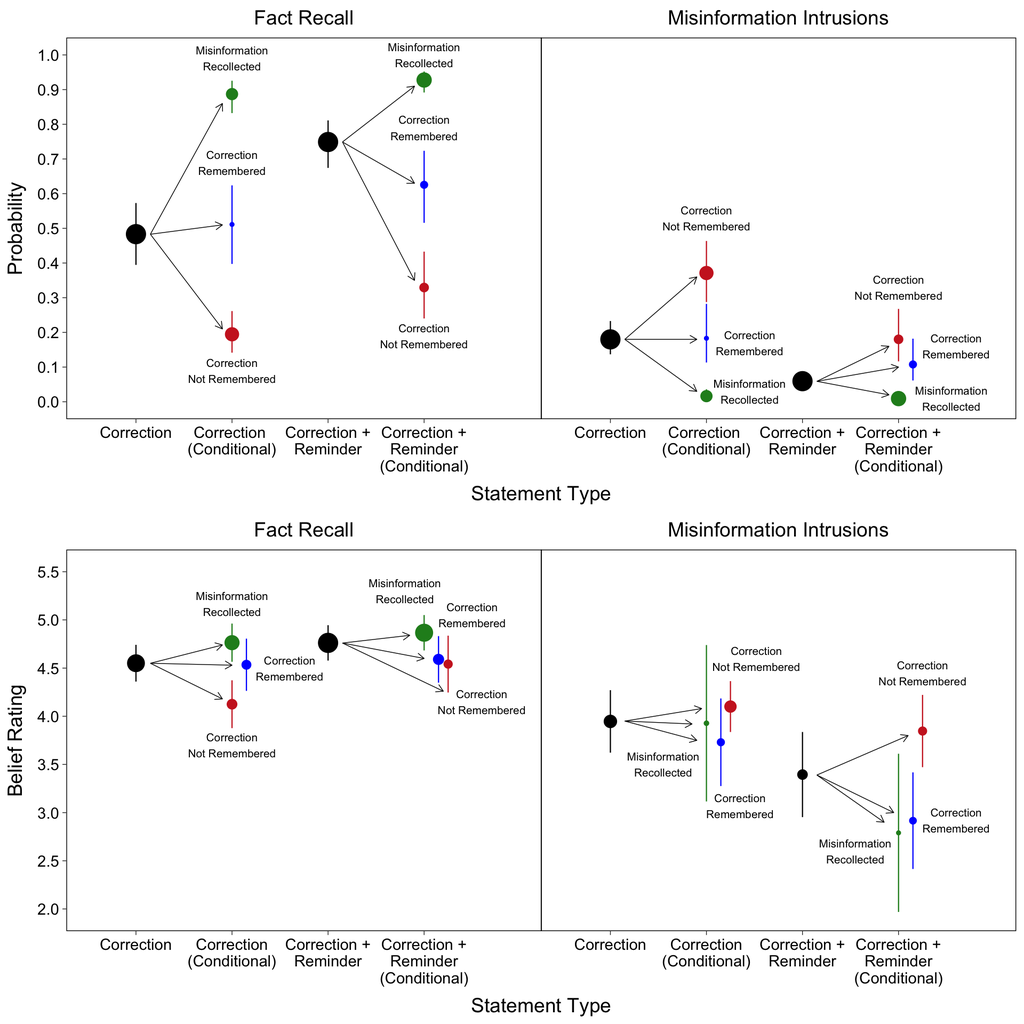

```r
e1_cond_recall_and_belief_plots <- grid.arrange(e1_recall_cond, e1_belief_cond, nrow = 2)
```

```r
e1_cond_recall_and_belief_plots
```

```r
ggsave("Fig_3_E1_Conditional_Analyses.pdf", plot = e1_cond_recall_and_belief_plots, width = 10, height = 10, units = "in", dpi = 320)
ggsave("Fig_3_E1_Conditional_Analyses.png", plot = e1_cond_recall_and_belief_plots, width = 10, height = 10, units = "in", dpi = 320)
```